# A Composition Benchmark for UI Claims Intensity

How Much of Low UI Coverage Is About Who Is Unemployed?

Author

Aryan Safi

Published

April 8, 2026

```r
library(tidyverse)
library(arrow)
library(fredr)
library(here)
library(ggsci)
library(scales)
library(gt)
library(lubridate)
library(patchwork)
library(fixest)
library(modelsummary)
library(prophet)

here::i_am("ui_composition_benchmark.qmd")
fredr_set_key("ccd350785a210a7653a20d02ce92d83a")

read_final_parquet <- function(filename) {
  path <- here("data", "final", filename)
  if (!file.exists(path)) stop("Missing derived dataset: ", path)
  arrow::read_parquet(path) |> as_tibble()
}

fredr_retry <- function(series_id, ..., max_tries = 5, wait_secs = 3) {
  last_err <- NULL
  for (i in seq_len(max_tries)) {
    result <- tryCatch(fredr(series_id, ...), error = function(e) e)
    if (!inherits(result, "error")) return(result)
    last_err <- result
    if (i < max_tries) Sys.sleep(wait_secs)
  }
  stop("FRED API failed after ", max_tries, " attempts for ", series_id, ": ",
       conditionMessage(last_err))
}

theme_report <- theme_minimal(base_size = 11, base_family = "sans") +
  theme(
    plot.title = element_text(face = "bold", size = 13),
    plot.subtitle = element_text(color = "grey50", size = 9),
    plot.caption = element_text(color = "grey60", size = 7, hjust = 0),
    panel.grid.minor = element_blank(),
    panel.grid.major.x = element_blank(),
    axis.title = element_text(size = 9, color = "grey40"),
    axis.text = element_text(size = 8, color = "grey50"),
    legend.position = "top",
    legend.text = element_text(size = 8),
    legend.title = element_blank()
  )
theme_set(theme_report)

cause_order <- c("Temporary Layoff", "Permanent Job Losers", "Completed Temp Job",
                 "Job Leavers", "Reentrants", "New Entrants")
group_order <- c("Job Separations", "Labor Force Entry")
cause_cols <- pal_jco()(6); names(cause_cols) <- cause_order
group_cols <- c("Job Separations" = "#0073C2", "Labor Force Entry" = "#EFC000")

recessions <- tibble(
  start = as.Date(c("2001-03-01", "2007-12-01", "2020-02-01")),
  end = as.Date(c("2001-11-01", "2009-06-01", "2020-04-01"))
)
recessions_long <- tibble(
  start = as.Date(c("1973-11-01", "1980-01-01", "1981-07-01",
                    "1990-07-01", "2001-03-01", "2007-12-01", "2020-02-01")),
  end = as.Date(c("1975-03-01", "1980-07-01", "1982-11-01",
                  "1991-03-01", "2001-11-01", "2009-06-01", "2020-04-01"))
)
add_recessions <- function(p, alpha = 0.08) {
  p + annotate("rect", xmin = recessions$start, xmax = recessions$end,
               ymin = -Inf, ymax = Inf, fill = "grey40", alpha = alpha)
}

msummary_styled <- function(models, title, notes) {
  msummary(
    models,
    stars = c("*" = 0.10, "**" = 0.05, "***" = 0.01),
    gof_map = c("nobs", "r.squared", "adj.r.squared", "within.r.squared"),
    title = title,
    notes = notes,
    output = "gt"
  ) |> tab_options(table.font.size = px(11))
}

fred_cause <- read_final_parquet("unemployment_fred_monthly.parquet") |>
  mutate(date = as.Date(date))
takeup_monthly <- read_final_parquet("ui_national_takeup_monthly.parquet") |>
  mutate(month = as.Date(month))
takeup_cause_df <- read_final_parquet("ui_national_takeup_cause.parquet") |>
  mutate(date = as.Date(date), month_of_year = factor(month_of_year, levels = month.abb))
nativity_shares <- read_final_parquet("unemployment_nativity_shares.parquet") |>
  mutate(date = as.Date(date))
fourway_nativity <- read_final_parquet("unemployment_fourway_nativity.parquet") |>
  mutate(date = as.Date(date))
dominant_profiles <- read_final_parquet("unemployment_dominant_profiles.parquet") |>
  mutate(
    cause = factor(cause, levels = cause_order),
    dimension = factor(dimension, levels = c("Age", "Education", "Sex", "Race/Ethnicity",
                                             "Occupation", "Class", "Foreign Born", "Noncitizen"))
  )
dominant_profile_ratios <- read_final_parquet("unemployment_dominant_profile_ratios.parquet") |>
  mutate(
    cause = factor(cause, levels = cause_order),
    dimension = factor(dimension, levels = c("Age", "Education", "Sex", "Race/Ethnicity",
                                             "Occupation", "Class", "Foreign Born", "Noncitizen"))
  )
panel_year <- read_final_parquet("ui_takeup_panel_state_year_analysis_ready.parquet") |>
  mutate(date = as.Date(period_start)) |>
  filter(year <= 2025)
```

# Abstract

The share of unemployed Americans receiving unemployment insurance benefits has fallen sharply over time. Yet the headline unemployment rate includes groups whom UI was never designed to cover. This report reconstructs the archived composition benchmark using the current parquet-backed workflow. The composition of unemployment explains a meaningful share of claims-intensity variation, but a substantial residual gap persists, especially in recent years.

# 1. Introduction

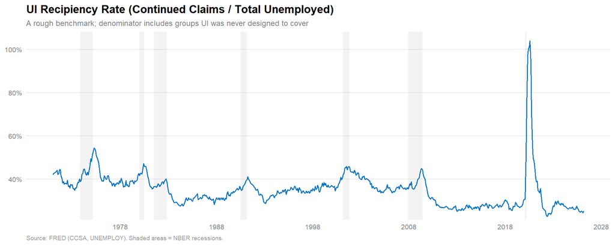

Figure 1: UI recipiency rate: continued claims as a share of total unemployed, 1971-present. Monthly data; continued claims (CCSA, weekly SA) are averaged within each month and divided by total unemployed (UNEMPLOY, in thousands, SA). Gray bands denote NBER recessions.

```r
recipiency_raw <- bind_rows(
  fredr_retry("CCSA", observation_start = as.Date("1971-01-01")) |>
    transmute(date, series = "CCSA", value),
  fredr_retry("UNEMPLOY", observation_start = as.Date("1971-01-01")) |>
    transmute(date, series = "UNEMPLOY", value)
)

recipiency_df <- recipiency_raw |>
  mutate(month = floor_date(date, "month")) |>
  summarise(.by = c(series, month), value = mean(value, na.rm = TRUE)) |>
  pivot_wider(names_from = series, values_from = value) |>
  filter(!is.na(CCSA), !is.na(UNEMPLOY), UNEMPLOY > 0) |>
  mutate(recipiency_rate = CCSA / (UNEMPLOY * 1000))

ggplot(recipiency_df, aes(month, recipiency_rate)) +
  annotate("rect", xmin = recessions_long$start, xmax = recessions_long$end,
           ymin = -Inf, ymax = Inf, fill = "grey40", alpha = 0.08) +
  geom_line(color = "#0073C2", linewidth = 0.6) +
  scale_y_continuous(labels = percent_format(accuracy = 1),
                     expand = expansion(mult = c(0.02, 0.05))) +
  scale_x_date(date_breaks = "10 years", date_labels = "%Y") +
  labs(
    title = "UI Recipiency Rate (Continued Claims / Total Unemployed)",
    subtitle = "A rough benchmark; denominator includes groups UI was never designed to cover",
    x = NULL, y = NULL,
    caption = "Source: FRED (CCSA, UNEMPLOY). Shaded areas = NBER recessions."
  )
```

```r
tibble(
  Category = cause_order,
  WHYUNEMP = 1:6,
  `BLS Definition` = c(
    "Given a return date or expects recall within 6 months",
    "Permanently separated; position eliminated, fired, or employer closed",
    "Temporary job or assignment has ended",
    "Voluntarily quit and now actively searching",
    "Previously held a job, left the labor force, now returned to searching",
    "Never held a job; actively looking for first one"
  ),
  `Two-Group` = c(rep("Job Separations", 4), rep("Labor Force Entry", 2))
) |>
  gt() |>
  tab_options(table.font.size = px(11), column_labels.font.weight = "bold",
              column_labels.background.color = "#2c3e50") |>
  tab_style(style = cell_text(color = "white"), locations = cells_column_labels()) |>
  tab_style(style = cell_fill(color = "#dce8f5"),
            locations = cells_body(rows = `Two-Group` == "Job Separations")) |>
  tab_style(style = cell_fill(color = "#fef3d0"),
            locations = cells_body(rows = `Two-Group` == "Labor Force Entry"))
```

Table 1: BLS reason-for-unemployment categories (CPS WHYUNEMP). The six categories are grouped into Job Separations and Labor Force Entry.

| Category | WHYUNEMP | BLS Definition | Two-Group |
| --- | --- | --- | --- |
| Temporary Layoff | 1 | Given a return date or expects recall within 6 months | Job Separations |
| Permanent Job Losers | 2 | Permanently separated; position eliminated, fired, or employer closed | Job Separations |
| Completed Temp Job | 3 | Temporary job or assignment has ended | Job Separations |
| Job Leavers | 4 | Voluntarily quit and now actively searching | Job Separations |
| Reentrants | 5 | Previously held a job, left the labor force, now returned to searching | Labor Force Entry |
| New Entrants | 6 | Never held a job; actively looking for first one | Labor Force Entry |

UI was originally designed for a narrower insured population: workers with sufficient prior earnings who lost jobs through no fault of their own. The six BLS reason-for-unemployment categories, temporary layoff, permanent job loss, completed temporary job, voluntary quit, reentry to the labor force, and new entry, proxy distance from that original insured population. New entrants have no prior work history. Reentrants may have been out of the labor force long enough to exhaust or never establish eligibility. Job leavers are typically disqualified. Only job losers and temporary layoffs are squarely within the program’s intended reach.

If the composition of unemployment shifts toward groups with weaker UI attachment, more new entrants, more reentrants, fewer permanent job losers, then the level of aggregate claims intensity historically associated with that unemployment mix will be lower. The empirical question is how much of the observed variation in UI claims intensity can be accounted for by the realized composition of unemployment under this reduced-form relationship, and how much remains as an unexplained residual.

This paper constructs a composition-based benchmark for UI claims intensity using the current local derived-data workflow. Using national claims series and an annual state panel that merges administrative claims outcomes with CPS-based unemployment composition, I estimate the reduced-form mapping from by-cause unemployment shares to claims intensity. The gap between observed and benchmark-predicted intensity quantifies the residual not accounted for by unemployment composition, the space where institutional, administrative, and behavioral factors may operate.

The standard recipiency rate and the claims-intensity measures used here differ primarily in denominator choice rather than underlying substance. Let $B_t$ denote UI beneficiaries, $U_t$ total unemployment, and $CE_t$ covered employment. Then claims intensity can be written as $B_t / CE_t = (B_t / U_t) \times (U_t / CE_t)$. This identity clarifies the relationship between the two traditions: the recipiency literature focuses on $B_t / U_t$, or UI receipt among the unemployed, whereas CC/CE and IC/CE incorporate both receipt behavior and the scale of unemployment relative to the covered-employment base. I use CC/CE and IC/CE because they are administratively grounded measures of aggregate UI caseload pressure, while unemployment composition is intended to capture how the claimant-relevant mix of the unemployed shifts over time. In that sense, the exercise here is not a pure model of recipiency conditional on unemployment, but a model of aggregate claims intensity in which recipiency-type composition effects are embedded within a covered-employment denominator.

The paper proceeds as follows. Section 2 reviews the relevant literature. Section 3 introduces a simple conceptual framework linking unemployment composition to expected claims intensity. Section 4 describes changes in the composition of unemployment over time. Section 5 describes the data. Section 6 prepares the claims and composition data. Section 7 presents each empirical exercise in sequence. Section 8 discusses interpretation. Section 9 concludes.

# 2. Literature Review

## 2.1 Measurement

Conclusions about the health of the UI system depend critically on the denominator. Wandner and Stengle (1997) developed six alternative recipiency measures and showed that the standard rate, beneficiaries divided by all unemployed, is arguably misleading because the denominator includes groups UI was never designed to cover. Their most restrictive measure, all-program weeks claimed divided by job losers unemployed fewer than 27 weeks, showed that UI covered more than four-fifths of short-term job losers, a far more favorable picture than the standard 25 to 30 percent suggests.

Wittenburg et al. (1999) produced the definitive Department of Labor meta-review, critically assessing prior studies and finding large differences in estimated effects across studies due to methodological variation. The present paper follows this tradition by being explicit about the denominator: covered employment, not total unemployment.

## 2.2 The Secular Decline

Burtless (1983) first documented the puzzle, finding that roughly 78 percent of the unemployed received UI in 1975 but only 45 percent did in 1982. Legislative changes explained about 60 percent of the decline. Blank and Card (1991) produced the most cited contribution: using PSID microdata matched with state eligibility rules, they showed that the fraction eligible for UI remained roughly constant over 1977 to 1987 and the entire decline was driven by falling take-up among eligibles. Anderson and Meyer (1997) resolved much of the remaining puzzle by showing that federal income taxation of benefits, phased in from 1978 to 1987, could account for most of the previously unexplained decline.

More recently, O’Leary et al. (2024) found the continued decline stems largely from changes in the industrial and occupational mix of employment interacting with UI program features. The Council of Economic Advisers (2024) reported that state differences in potential eligibility explain only 11 percent of recipiency rate variation, while most variation stems from other state policy and administrative choices.

## 2.3 Institutional Explanations

Lachowska, Sorkin, and Woodbury (2025) introduced an employer-side perspective using two-way fixed-effects models on Washington State administrative records. They found substantial firm effects on both claiming and appeals, with a strong negative correlation: firms that appeal more have lower claim rates. Their most striking finding is that the dominant targeting error is eligible non-claiming, 28 percent of eligibles, not ineligible receipt, 5 percent.

Budd and McCall (1997) showed that union blue-collar workers were 23 percent more likely to receive UI, consistent with an information and facilitation role. Auray and Fuller (2020) estimated that firm challenges account for 41 percent of total UI collection costs and that eliminating all challenges would raise take-up by 5.1 percentage points.

Ebenstein and Stange (2010) exploited the staggered introduction of telephone and Internet-based filing across states and found no appreciable impact on take-up, suggesting the barriers run deeper than transaction costs.

## 2.4 Racial and Demographic Disparities

Kuka and Stuart (2025) provided the most rigorous evidence on racial gaps: Black individuals who separate from a job are 30 percent less likely to receive UI and receive 46 percent fewer total benefits than White individuals, a gap stable over nearly 30 years. This gap stems primarily from lower take-up among eligible individuals, not eligibility differences. Skandalis, Marinescu, and Massenkoff (2022) showed that state rules alone create an 8.4 percent racial gap in entitlements because Black claimants disproportionately reside in less generous states.

## 2.5 Positioning This Paper

The literature already knows that job losers are more UI-relevant than new entrants or reentrants. What it has not systematically done is quantify the explanatory power of the by-cause composition channel for aggregate claims intensity in a panel setting and characterize the size and evolution of the residual gap. That is the contribution here. This paper is a composition-based benchmark, not the discovery of the composition idea. It occupies the space between the measurement papers, which define the right denominator, and the mechanism papers, which identify specific barriers to access.

# 3. Conceptual Framework

The central link between unemployment composition and UI claims intensity can be expressed in a simple decomposition. Let $y_{st}$ denote a claims-intensity measure, for example continued claims per covered employment, in state $s$ at time $t$, and let $s_{cst}$ denote the share of unemployment in state $s$ at time $t$ accounted for by cause $c$. Then:

$$y_{st} = \sum_c s_{cst} \cdot \lambda_c + \varepsilon_{st}
\tag{1}$$

where $\lambda_c$ is the reduced-form loading of cause $c$ on claims intensity and $\varepsilon_{st}$ is a residual not accounted for by composition. The composition-predicted component $\hat{y}_{st} = \sum_c s_{cst} \cdot \hat{\lambda}_c$ is a benchmark: the level of claims intensity historically associated with a given unemployment mix. I do not interpret the fitted values as the causal effect of unemployment composition on claims intensity. Instead, they represent a reduced-form benchmark for the level of claims intensity that the historical relationship in the data would predict given the realized composition of unemployment.

This benchmark is informative even though unemployment composition is not exogenous, because it summarizes an empirical regularity rather than identifying a pure causal channel. The by-cause shares are not randomly assigned treatments; they are jointly shaped by the same labor-market and policy shocks that affect claims intensity. The $\hat{\lambda}_c$ are therefore reduced-form loadings, not structural parameters. If the share of new entrants rises and new entrants have low $\hat{\lambda}$, benchmark-predicted intensity falls, but this need not reflect a mechanical compositional effect in isolation from the broader shock environment.

The residual $\varepsilon_{st}$ absorbs everything else:

- Administrative burden and hassle costs
- Employer contestation and experience-rated deterrence
- Benefit generosity and replacement rates
- State eligibility rules and policy design
- Information frictions and stigma
- Demographic disparities in access conditional on cause

The gap between observed and benchmark-predicted claims intensity, $y_{st} - \hat{y}_{st}$, is the portion not accounted for by unemployment composition under the historical reduced-form relationship. The empirical exercise estimates Equation 1 using national and state-panel regressions, then examines the size and time path of this residual.

# 4. Descriptive Background: Composition of Unemployment

This section documents how unemployment composition by reason has changed over time, emphasizing the shifts most relevant to UI claims intensity.

```r
fred_cause_long <- fred_cause |>
  select(date, all_of(paste0(cause_order, "_rate"))) |>
  pivot_longer(-date, names_to = "cause", values_to = "rate") |>
  mutate(cause = factor(str_remove(cause, "_rate"), levels = cause_order))

two_group_long <- fred_cause |>
  select(date, `Job Separations_rate`, `Labor Force Entry_rate`) |>
  pivot_longer(-date, names_to = "group", values_to = "rate") |>
  mutate(group = factor(str_remove(group, "_rate"), levels = group_order))

nativity_group_order <- c(
  "Foreign-Born Entrants",
  "Native-Born Entrants",
  "Foreign-Born Job Separators",
  "Native-Born Job Separators"
)

nativity_group_cols <- c(
  "Foreign-Born Entrants" = "#b8860b",
  "Native-Born Entrants" = "#ffe680",
  "Foreign-Born Job Separators" = "#003f7f",
  "Native-Born Job Separators" = "#66b2ff"
)

fourway_nativity_long <- fourway_nativity |>
  transmute(
    date,
    `Foreign-Born Job Separators` = `Foreign Born × Separations_rate`,
    `Native-Born Job Separators` = `Native Born × Separations_rate`,
    `Foreign-Born Entrants` = `Foreign Born × Entry_rate`,
    `Native-Born Entrants` = `Native Born × Entry_rate`,
    urate
  ) |>
  pivot_longer(-c(date, urate), names_to = "group", values_to = "rate") |>
  mutate(group = factor(group, levels = nativity_group_order))

fourway_nat_share_long <- nativity_shares |>
  filter(
    panel == "share_of_total_unemployed",
    series %in% c("LF Entrants", "Job Separators", "LF Entrants × FB", "Job Separators × FB")
  ) |>
  transmute(date, series = as.character(series), share) |>
  pivot_wider(names_from = series, values_from = share) |>
  transmute(
    date,
    `Foreign-Born Entrants` = `LF Entrants × FB`,
    `Native-Born Entrants` = `LF Entrants` - `LF Entrants × FB`,
    `Foreign-Born Job Separators` = `Job Separators × FB`,
    `Native-Born Job Separators` = `Job Separators` - `Job Separators × FB`
  ) |>
  pivot_longer(-date, names_to = "group", values_to = "share") |>
  mutate(group = factor(group, levels = nativity_group_order))
```

## 4.1 Unemployment Rate by Cause

The stacked bars below show each cause’s contribution to the headline unemployment rate since 1994. Job separations dominate cyclical variation, while labor force entry contributes a relatively stable base.

**Six-Way**

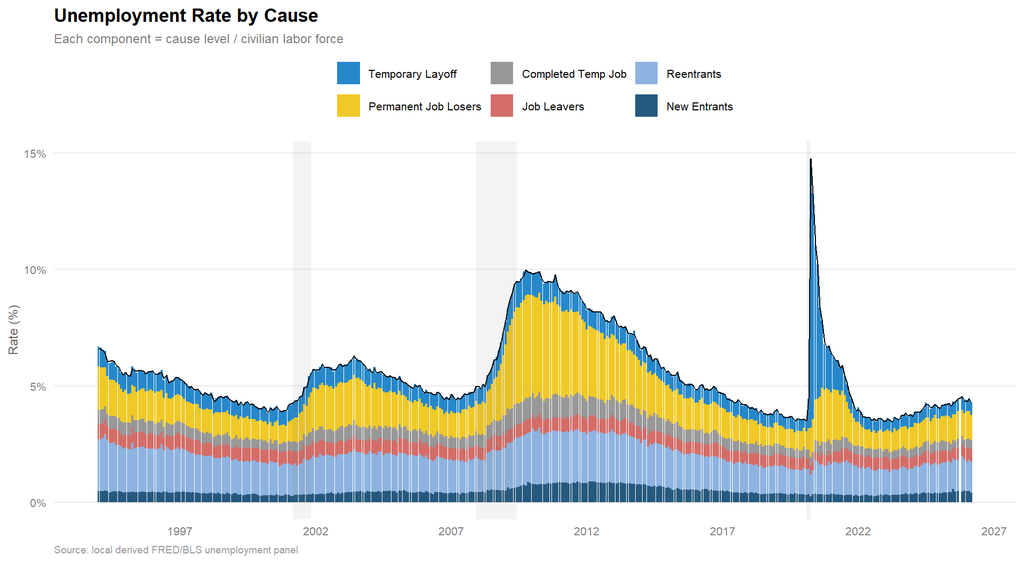

Figure 2: Unemployment rate decomposed by cause. Bars stack to total unemployment rate.

```r
add_recessions(
  ggplot(fred_cause_long, aes(date, rate, fill = cause)) +
    geom_col(alpha = 0.85, width = 28) +
    geom_line(data = fred_cause, aes(y = urate, fill = NULL), color = "black", linewidth = 0.4) +
    scale_fill_manual(values = cause_cols) +
    scale_y_continuous(labels = \(x) paste0(x, "%")) +
    scale_x_date(date_breaks = "5 years", date_labels = "%Y") +
    labs(
      title = "Unemployment Rate by Cause",
      subtitle = "Each component = cause level / civilian labor force",
      x = NULL,
      y = "Rate (%)",
      caption = "Source: local derived FRED/BLS unemployment panel"
    )
)
```

**Two-Group**

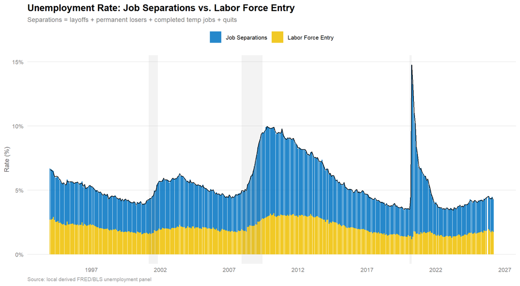

Figure 3: Unemployment rate decomposed into job separations versus labor force entry.

```r
add_recessions(
  ggplot(two_group_long, aes(date, rate, fill = group)) +
    geom_col(alpha = 0.85, width = 28) +
    geom_line(data = fred_cause, aes(y = urate, fill = NULL), color = "black", linewidth = 0.4) +
    scale_fill_manual(values = group_cols) +
    scale_y_continuous(labels = \(x) paste0(x, "%")) +
    scale_x_date(date_breaks = "5 years", date_labels = "%Y") +
    labs(
      title = "Unemployment Rate: Job Separations vs. Labor Force Entry",
      subtitle = "Separations = layoffs + permanent losers + completed temp jobs + quits",
      x = NULL,
      y = "Rate (%)",
      caption = "Source: local derived FRED/BLS unemployment panel"
    )
)
```

**Two-Group x Nativity**

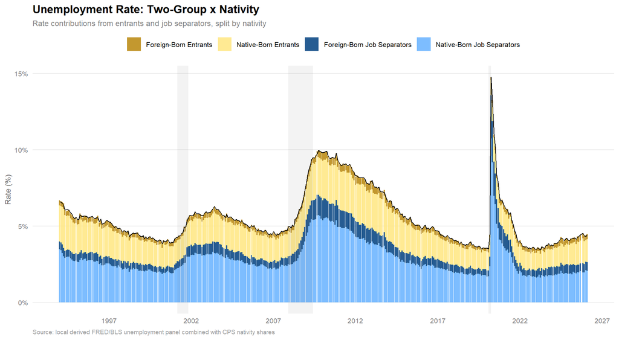

Figure 4: Unemployment rate decomposed into entrants versus job separators, split by nativity.

```r
add_recessions(
  ggplot(fourway_nativity_long, aes(date, rate, fill = group)) +
    geom_col(alpha = 0.85, width = 28) +
    geom_line(
      data = fourway_nativity,
      aes(y = urate, fill = NULL),
      color = "black",
      linewidth = 0.4
    ) +
    scale_fill_manual(values = nativity_group_cols) +
    scale_y_continuous(labels = \(x) paste0(x, "%")) +
    scale_x_date(date_breaks = "5 years", date_labels = "%Y") +
    labs(
      title = "Unemployment Rate: Two-Group x Nativity",
      subtitle = "Rate contributions from entrants and job separators, split by nativity",
      x = NULL,
      y = "Rate (%)",
      caption = "Source: local derived FRED/BLS unemployment panel combined with CPS nativity shares"
    )
)
```

## 4.2 Year-Over-Year Changes

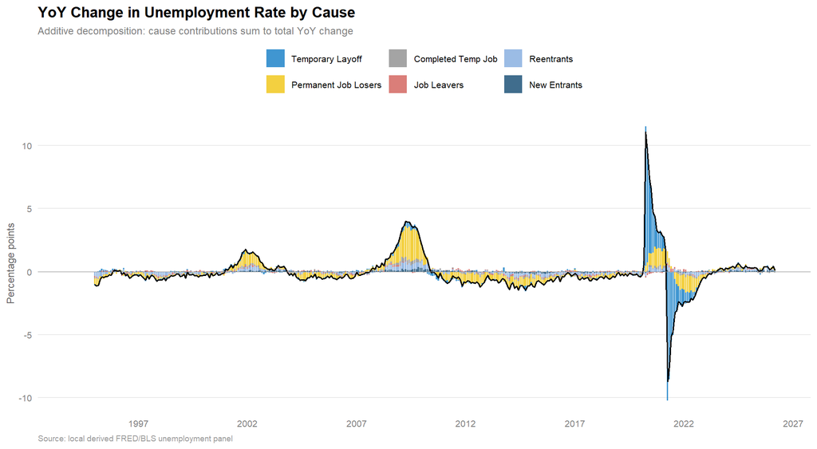

Figure 5: Year-over-year change in unemployment rate decomposed by cause.

```r
fred_cause |>
  arrange(date) |>
  mutate(across(all_of(paste0(cause_order, "_rate")), \(x) x - lag(x, 12), .names = "{.col}_chg"),
         urate_chg = urate - lag(urate, 12)) |>
  select(date, ends_with("_chg"), urate_chg) |>
  pivot_longer(cols = ends_with("_rate_chg"), names_to = "cause", values_to = "chg") |>
  mutate(cause = factor(str_remove(cause, "_rate_chg"), levels = cause_order)) |>
  ggplot(aes(date, chg, fill = cause)) +
  geom_col(alpha = 0.75, width = 25) +
  geom_line(data = fred_cause |>
              arrange(date) |>
              mutate(urate_chg = urate - lag(urate, 12)),
            aes(y = urate_chg, fill = NULL), color = "black", linewidth = 0.6) +
  geom_hline(yintercept = 0, color = "grey60", linewidth = 0.3) +
  scale_fill_manual(values = cause_cols) +
  scale_x_date(date_breaks = "5 years", date_labels = "%Y") +
  labs(
    title = "YoY Change in Unemployment Rate by Cause",
    subtitle = "Additive decomposition: cause contributions sum to total YoY change",
    x = NULL,
    y = "Percentage points",
    caption = "Source: local derived FRED/BLS unemployment panel"
  )
```

## 4.3 Composition Shares Over Time

For UI claims intensity, the relevant object is not the rate contribution of each cause but its share of total unemployment. A rising share of new entrants or reentrants means a larger fraction of the unemployed pool falls outside the traditional insured population.

**Six-Way**

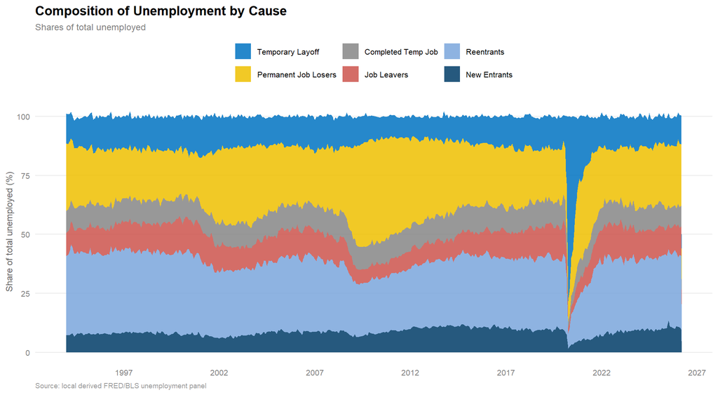

Figure 6: Composition of unemployment by cause (shares of total unemployed). Labor force entrants comprise a large share of the unemployed pool outside recessions.

```r
fred_cause |>
  transmute(
    date,
    `Temporary Layoff` = `Temporary Layoff` / Total * 100,
    `Permanent Job Losers` = `Permanent Job Losers` / Total * 100,
    `Completed Temp Job` = `Completed Temp Job` / Total * 100,
    `Job Leavers` = `Job Leavers` / Total * 100,
    Reentrants = Reentrants / Total * 100,
    `New Entrants` = `New Entrants` / Total * 100
  ) |>
  pivot_longer(-date, names_to = "cause", values_to = "share") |>
  mutate(cause = factor(cause, levels = cause_order)) |>
  ggplot(aes(date, share, fill = cause)) +
  geom_area(alpha = 0.85) +
  scale_fill_manual(values = cause_cols) +
  scale_x_date(date_breaks = "5 years", date_labels = "%Y") +
  labs(
    title = "Composition of Unemployment by Cause",
    subtitle = "Shares of total unemployed",
    x = NULL,
    y = "Share of total unemployed (%)",
    caption = "Source: local derived FRED/BLS unemployment panel"
  )
```

**Two-Group x Nativity**

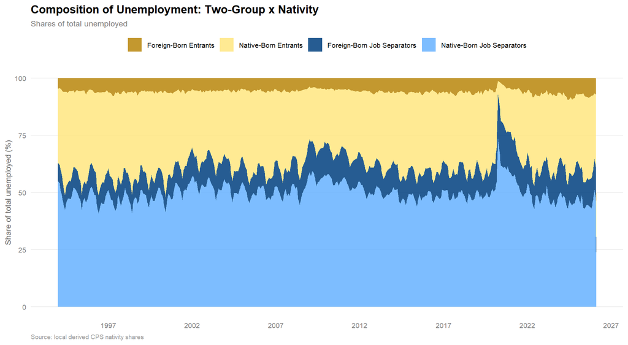

Figure 7: Composition of unemployment by nativity-by-two-group cells (shares of total unemployed).

```r
ggplot(fourway_nat_share_long, aes(date, share, fill = group)) +
  geom_area(alpha = 0.85) +
  scale_fill_manual(values = nativity_group_cols) +
  scale_x_date(date_breaks = "5 years", date_labels = "%Y") +
  labs(
    title = "Composition of Unemployment: Two-Group x Nativity",
    subtitle = "Shares of total unemployed",
    x = NULL,
    y = "Share of total unemployed (%)",
    caption = "Source: local derived CPS nativity shares"
  )
```

The key pattern for UI is straightforward: outside of recessions, labor force entrants, reentrants plus new entrants, comprise a large share of the unemployed. These are predominantly individuals with weak or no UI eligibility. During recessions, job losers surge and the entrant share compresses. The level of aggregate claims intensity historically associated with a given unemployment mix should therefore be higher in recessions and lower in expansions, even if nothing changes about the institutional environment.

### Correlation with Claims Intensity

To verify that the compositional patterns documented above are reflected in claims-intensity data, the figure below shows the correlation between each cause’s share of unemployment and the two claims-intensity measures after a common seasonal-adjustment procedure. In the pandemic-exclusion sample, completed temporary jobs are close to neutral, which motivates their role as the omitted reference category in the regressions that follow.

Seasonal adjustment matters here. Although some underlying labor-market series are already seasonally adjusted, the claims-intensity ratios and the cause shares can inherit residual seasonality through their denominators. To ensure the correlations reflect co-movement in trend and cycle rather than shared within-year patterns, all eight series entering the correlation, six cause shares plus CC/CE and IC/CE, are seasonally adjusted using Prophet before the correlations are computed.

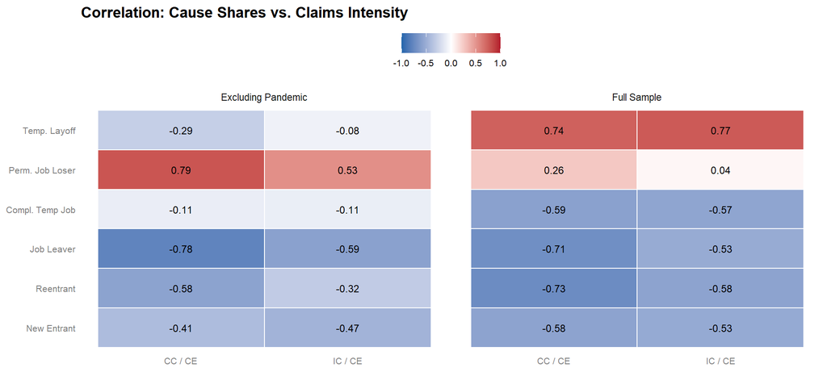

```r
prophet_sa <- function(dates, values) {
  df_in <- tibble(ds = as.Date(dates), y = as.numeric(values)) |> drop_na()
  m <- suppressMessages(prophet(df_in, yearly.seasonality = TRUE, weekly.seasonality = FALSE,
                                daily.seasonality = FALSE, seasonality.mode = "additive",
                                uncertainty.samples = 0))
  fc <- suppressMessages(predict(m, df_in))
  tibble(ds = df_in$ds, y_sa = df_in$y - fc$yearly)
}

corr_raw <- takeup_cause_df |>
  transmute(
    date,
    temp_layoff_raw = temp_layoff_share,
    perm_job_loser_raw = perm_job_loser_share,
    compl_temp_job_raw = completed_temp_job_share,
    job_leaver_raw = job_leaver_share,
    reentrant_raw = reentrant_share,
    new_entrant_raw = new_entrant_share,
    cc_ce_raw = cc_ce,
    ic_ce_raw = ic_ce
  )

vars <- c("temp_layoff_raw", "perm_job_loser_raw", "compl_temp_job_raw", "job_leaver_raw",
          "reentrant_raw", "new_entrant_raw", "cc_ce_raw", "ic_ce_raw")
nice <- c("Temp. Layoff", "Perm. Job Loser", "Compl. Temp Job", "Job Leaver",
          "Reentrant", "New Entrant", "CC / CE", "IC / CE")

corr_sa <- corr_raw |> select(date)
for (i in seq_along(vars)) {
  corr_sa <- corr_sa |>
    left_join(prophet_sa(corr_raw$date, corr_raw[[vars[i]]]) |>
                rename(date = ds, !!nice[i] := y_sa),
              by = "date")
}

compute_corr_long <- function(data) {
  share_vars <- nice[1:6]
  out_vars <- nice[7:8]
  mat <- cor(data[, c(share_vars, out_vars)], use = "pairwise.complete.obs")
  mat[share_vars, out_vars] |>
    as.data.frame() |>
    rownames_to_column("Cause Share") |>
    pivot_longer(-`Cause Share`, names_to = "Outcome", values_to = "r") |>
    mutate(`Cause Share` = factor(`Cause Share`, levels = rev(share_vars)))
}

bind_rows(
  compute_corr_long(corr_sa) |> mutate(panel = "Full Sample"),
  compute_corr_long(corr_sa |>
                      filter(date < as.Date("2020-03-01") | date > as.Date("2021-12-01"))) |>
    mutate(panel = "Excluding Pandemic")
) |>
  ggplot(aes(Outcome, `Cause Share`, fill = r)) +
  geom_tile(color = "white", linewidth = 0.5) +
  geom_text(aes(label = sprintf("%.2f", r)), size = 3.2) +
  scale_fill_gradient2(low = "#2166AC", mid = "white", high = "#B2182B",
                       midpoint = 0, limits = c(-1, 1), name = "Correlation") +
  facet_wrap(~panel) +
  labs(title = "Correlation: Cause Shares vs. Claims Intensity", x = NULL, y = NULL) +
  theme(panel.grid = element_blank())
```

In the pandemic-exclusion sample, completed temporary jobs stand out as essentially uncorrelated with either outcome, motivating their use as the omitted reference category in the regressions that follow. Permanent job losers show the strongest positive correlation with claims intensity, consistent with their position as the most UI-relevant group. New entrants, reentrants, and job leavers are negatively correlated with both outcomes, consistent with their weaker UI attachment.

## 4.4 Who Are the Unemployed by Cause?

The compositional shifts documented above raise a natural question: who are the people in each cause category, and has their demographic profile changed over time? The current build stores precomputed dominant-profile summaries, which makes it possible to recreate the archived profile comparisons without re-reading CPS microdata during render.

Four views are presented for each cause: (i) a pooled profile showing the dominant demographic group’s share along each dimension, (ii) a 2025-vs-pooled delta showing how the current composition differs from the historical average, (iii) a pooled representation ratio (cause-group share ÷ labor force share, where values above 1 indicate overrepresentation and below 1 indicate underrepresentation), and (iv) the 2025-vs-pooled change in the representation ratio. Together, these charts distinguish between groups that are large in a cause category simply because they are large in the labor force versus groups that are genuinely overrepresented relative to their labor force presence.

```r
plot_dominant_radar_single <- function(profile_df, cause_name, subtitle) {
  plot_df <- profile_df |>
    filter(cause == cause_name) |>
    arrange(dimension) |>
    mutate(axis_id = row_number())

  n_axes <- nrow(plot_df)
  angles <- pi / 2 - 2 * pi * (seq_len(n_axes) - 1) / n_axes
  radial_breaks <- c(0, 0.25, 0.50, 0.75, 1.00)

  point_df <- plot_df |>
    mutate(
      angle = angles,
      x = share * cos(angle),
      y = share * sin(angle)
    )

  closed_df <- bind_rows(point_df, slice(point_df, 1))

  spoke_df <- tibble(
    axis_id = seq_len(n_axes),
    angle = angles,
    x = 0,
    y = 0,
    xend = cos(angle),
    yend = sin(angle)
  )

  ring_df <- map_dfr(
    radial_breaks[-1],
    \(ring) {
      tibble(
        ring = ring,
        axis_id = c(seq_len(n_axes), 1L),
        angle = angles[c(seq_len(n_axes), 1L)],
        x = ring * cos(angle),
        y = ring * sin(angle)
      )
    }
  )

  axis_label_df <- point_df |>
    transmute(
      dimension,
      angle,
      label_x = 1.17 * cos(angle),
      label_y = 1.17 * sin(angle),
      hjust = case_when(
        label_x > 0.15 ~ 0,
        label_x < -0.15 ~ 1,
        TRUE ~ 0.5
      ),
      vjust = case_when(
        label_y > 0.15 ~ 0,
        label_y < -0.15 ~ 1,
        TRUE ~ 0.5
      )
    )

  point_label_df <- point_df |>
    transmute(
      axis_id,
      angle,
      point_label = label,
      label_radius = case_when(
        share >= 0.72 ~ pmax(share - 0.14, 0.16),
        TRUE ~ pmin(share + 0.11, 0.88)
      ),
      tangent_shift = if_else(axis_id %% 2 == 0, 0.045, -0.045),
      label_x = label_radius * cos(angle) + tangent_shift * (-sin(angle)),
      label_y = label_radius * sin(angle) + tangent_shift * cos(angle),
      hjust = case_when(
        label_x > 0.18 ~ 0,
        label_x < -0.18 ~ 1,
        TRUE ~ 0.5
      ),
      vjust = case_when(
        label_y > 0.18 ~ 0,
        label_y < -0.18 ~ 1,
        TRUE ~ 0.5
      )
    )

  radial_label_df <- tibble(
    ring = radial_breaks,
    x = radial_breaks,
    y = 0.02,
    label = percent(radial_breaks, accuracy = 1)
  )

  ggplot() +
    geom_path(
      data = filter(ring_df, ring < 1),
      aes(x = x, y = y, group = ring),
      color = "grey72",
      linewidth = 0.15
    ) +
    geom_path(
      data = filter(ring_df, ring == 1),
      aes(x = x, y = y, group = ring),
      color = "grey72",
      linewidth = 0.15
    ) +
    geom_segment(
      data = spoke_df,
      aes(x = x, y = y, xend = xend, yend = yend),
      color = "grey76",
      linewidth = 0.15
    ) +
    geom_polygon(
      data = closed_df,
      aes(x = x, y = y),
      fill = scales::alpha(cause_cols[[cause_name]], 0.45),
      color = cause_cols[[cause_name]],
      linewidth = 0.15,
      linejoin = "round"
    ) +
    geom_point(
      data = point_df,
      aes(x = x, y = y),
      color = cause_cols[[cause_name]],
      fill = cause_cols[[cause_name]],
      shape = 21,
      stroke = 0.2,
      size = 1.4
    ) +
    geom_text(
      data = point_label_df,
      aes(x = label_x, y = label_y, label = point_label, hjust = hjust, vjust = vjust),
      size = 2.7,
      lineheight = 0.92,
      color = cause_cols[[cause_name]]
    ) +
    geom_text(
      data = axis_label_df,
      aes(x = label_x, y = label_y, label = dimension, hjust = hjust, vjust = vjust),
      size = 3.6,
      lineheight = 0.9
    ) +
    geom_text(
      data = radial_label_df,
      aes(x = x, y = y, label = label),
      color = "grey65",
      size = 3.3,
      hjust = 0.5,
      vjust = 0
    ) +
    coord_equal(clip = "off") +
    xlim(-1.28, 1.28) +
    ylim(-1.26, 1.28) +
    labs(
      title = cause_name,
      subtitle = subtitle,
      x = NULL,
      y = NULL
    ) +
    theme_report +
    theme(
      axis.text = element_blank(),
      axis.ticks = element_blank(),
      axis.line = element_blank(),
      panel.grid = element_blank(),
      plot.margin = margin(20, 35, 20, 35)
    )
}

plot_dominant_radar_delta <- function(profile_df, cause_name, subtitle, max_abs_delta = 0.20) {
  plot_df <- profile_df |>
    filter(cause == cause_name) |>
    arrange(dimension) |>
    mutate(axis_id = row_number())

  n_axes <- nrow(plot_df)
  angles <- pi / 2 - 2 * pi * (seq_len(n_axes) - 1) / n_axes
  radial_breaks <- c(-0.20, -0.10, 0, 0.10, 0.20)
  radial_positions <- scales::rescale(
    radial_breaks,
    to = c(0, 1),
    from = c(-max_abs_delta, max_abs_delta)
  )

  point_df <- plot_df |>
    mutate(
      angle = angles,
      radius = scales::rescale(
        delta,
        to = c(0, 1),
        from = c(-max_abs_delta, max_abs_delta)
      ),
      x = radius * cos(angle),
      y = radius * sin(angle)
    )

  closed_df <- bind_rows(point_df, slice(point_df, 1))

  spoke_df <- tibble(
    axis_id = seq_len(n_axes),
    angle = angles,
    x = 0,
    y = 0,
    xend = cos(angle),
    yend = sin(angle)
  )

  ring_df <- map_dfr(
    seq_along(radial_breaks),
    \(i) {
      tibble(
        ring_value = radial_breaks[[i]],
        ring_position = radial_positions[[i]],
        axis_id = c(seq_len(n_axes), 1L),
        angle = angles[c(seq_len(n_axes), 1L)],
        x = radial_positions[[i]] * cos(angle),
        y = radial_positions[[i]] * sin(angle)
      )
    }
  )

  axis_label_df <- point_df |>
    transmute(
      dimension,
      angle,
      label_x = 1.17 * cos(angle),
      label_y = 1.17 * sin(angle),
      hjust = case_when(
        label_x > 0.15 ~ 0,
        label_x < -0.15 ~ 1,
        TRUE ~ 0.5
      ),
      vjust = case_when(
        label_y > 0.15 ~ 0,
        label_y < -0.15 ~ 1,
        TRUE ~ 0.5
      )
    )

  point_label_df <- point_df |>
    transmute(
      axis_id,
      angle,
      point_label = label,
      label_radius = case_when(
        radius >= 0.80 ~ pmax(radius - 0.16, 0.14),
        radius <= 0.20 ~ pmin(radius + 0.16, 0.32),
        TRUE ~ pmin(radius + 0.11, 0.90)
      ),
      tangent_shift = if_else(axis_id %% 2 == 0, 0.045, -0.045),
      label_x = label_radius * cos(angle) + tangent_shift * (-sin(angle)),
      label_y = label_radius * sin(angle) + tangent_shift * cos(angle),
      hjust = case_when(
        label_x > 0.18 ~ 0,
        label_x < -0.18 ~ 1,
        TRUE ~ 0.5
      ),
      vjust = case_when(
        label_y > 0.18 ~ 0,
        label_y < -0.18 ~ 1,
        TRUE ~ 0.5
      )
    )
```

```r
  radial_label_df <- tibble(
    ring_value = radial_breaks,
    x = radial_positions,
    y = 0.02,
    label = paste0(if_else(radial_breaks > 0, "+", ""), number(radial_breaks * 100, accuracy = 0.1))
  )

  ggplot() +
    geom_path(
      data = filter(ring_df, abs(ring_value) > 1e-9),
      aes(x = x, y = y, group = ring_value),
      color = "grey78",
      linewidth = 0.15
    ) +
    geom_path(
      data = filter(ring_df, abs(ring_value) <= 1e-9),
      aes(x = x, y = y, group = ring_value),
      color = "grey40",
      linewidth = 0.6
    ) +
    geom_segment(
      data = spoke_df,
      aes(x = x, y = y, xend = xend, yend = yend),
      color = "grey80",
      linewidth = 0.15
    ) +
    geom_polygon(
      data = closed_df,
      aes(x = x, y = y),
      fill = scales::alpha(cause_cols[[cause_name]], 0.22),
      color = cause_cols[[cause_name]],
      linewidth = 0.2,
      linejoin = "round"
    ) +
    geom_point(
      data = point_df,
      aes(x = x, y = y),
      color = cause_cols[[cause_name]],
      fill = cause_cols[[cause_name]],
      shape = 21,
      stroke = 0.2,
      size = 1.4
    ) +
    geom_text(
      data = point_label_df,
      aes(x = label_x, y = label_y, label = point_label, hjust = hjust, vjust = vjust),
      size = 2.5,
      lineheight = 0.92,
      color = cause_cols[[cause_name]]
    ) +
    geom_text(
      data = axis_label_df,
      aes(x = label_x, y = label_y, label = dimension, hjust = hjust, vjust = vjust),
      size = 3.6,
      lineheight = 0.9
    ) +
    geom_text(
      data = radial_label_df,
      aes(x = x, y = y, label = label),
      color = "grey60",
      size = 3.0,
      hjust = 0.5,
      vjust = 0
    ) +
    coord_equal(clip = "off") +
    xlim(-1.28, 1.28) +
    ylim(-1.26, 1.28) +
    labs(
      title = cause_name,
      subtitle = subtitle,
      x = NULL,
      y = NULL
    ) +
    theme_report +
    theme(
      axis.text = element_blank(),
      axis.ticks = element_blank(),
      axis.line = element_blank(),
      panel.grid = element_blank(),
      plot.margin = margin(20, 35, 20, 35)
    )
}

plot_dominant_radar_ratio <- function(ratio_df, cause_name, subtitle, max_ratio = 3.0) {
  plot_df <- ratio_df |>
    filter(cause == cause_name) |>
    arrange(dimension) |>
    mutate(axis_id = row_number())

  n_axes <- nrow(plot_df)
  angles <- pi / 2 - 2 * pi * (seq_len(n_axes) - 1) / n_axes
  radial_breaks <- c(0, 0.5, 1.0, 1.5, 2.0, max_ratio)

  point_df <- plot_df |>
    mutate(
      angle = angles,
      radius = pmin(ratio, max_ratio) / max_ratio,
      x = radius * cos(angle),
      y = radius * sin(angle)
    )

  closed_df <- bind_rows(point_df, slice(point_df, 1))

  spoke_df <- tibble(
    axis_id = seq_len(n_axes),
    angle = angles,
    x = 0, y = 0,
    xend = cos(angle), yend = sin(angle)
  )

  ring_df <- map_dfr(radial_breaks, \(ring) {
    tibble(
      ring = ring,
      ring_radius = ring / max_ratio,
      axis_id = c(seq_len(n_axes), 1L),
      angle = angles[c(seq_len(n_axes), 1L)],
      x = (ring / max_ratio) * cos(angle),
      y = (ring / max_ratio) * sin(angle)
    )
  })

  axis_label_df <- point_df |>
    transmute(
      dimension, angle,
      label_x = 1.17 * cos(angle),
      label_y = 1.17 * sin(angle),
      hjust = case_when(label_x > 0.15 ~ 0, label_x < -0.15 ~ 1, TRUE ~ 0.5),
      vjust = case_when(label_y > 0.15 ~ 0, label_y < -0.15 ~ 1, TRUE ~ 0.5)
    )

  point_label_df <- point_df |>
    transmute(
      axis_id, angle,
      point_label = label,
      label_radius = case_when(
        radius >= 0.72 ~ pmax(radius - 0.14, 0.16),
        TRUE ~ pmin(radius + 0.11, 0.88)
      ),
      tangent_shift = if_else(axis_id %% 2 == 0, 0.045, -0.045),
      label_x = label_radius * cos(angle) + tangent_shift * (-sin(angle)),
      label_y = label_radius * sin(angle) + tangent_shift * cos(angle),
      hjust = case_when(label_x > 0.18 ~ 0, label_x < -0.18 ~ 1, TRUE ~ 0.5),
      vjust = case_when(label_y > 0.18 ~ 0, label_y < -0.18 ~ 1, TRUE ~ 0.5)
    )

  radial_label_df <- tibble(
    ring = radial_breaks,
    x = radial_breaks / max_ratio,
    y = 0.02,
    label = paste0(number(radial_breaks, accuracy = 0.1), "x")
  )

  unity_radius <- 1.0 / max_ratio

  ggplot() +
    geom_path(
      data = filter(ring_df, abs(ring - 1.0) > 0.01),
      aes(x = x, y = y, group = ring),
      color = "grey72", linewidth = 0.15
    ) +
    geom_path(
      data = filter(ring_df, abs(ring - 1.0) <= 0.01),
      aes(x = x, y = y, group = ring),
      color = "grey40", linewidth = 0.6, linetype = "dashed"
    ) +
    geom_segment(
      data = spoke_df,
      aes(x = x, y = y, xend = xend, yend = yend),
      color = "grey76", linewidth = 0.15
    ) +
    geom_polygon(
      data = closed_df,
      aes(x = x, y = y),
      fill = scales::alpha(cause_cols[[cause_name]], 0.45),
      color = cause_cols[[cause_name]],
      linewidth = 0.15, linejoin = "round"
    ) +
    geom_point(
      data = point_df,
      aes(x = x, y = y),
      color = cause_cols[[cause_name]],
      fill = cause_cols[[cause_name]],
      shape = 21, stroke = 0.2, size = 1.4
    ) +
    geom_text(
      data = point_label_df,
      aes(x = label_x, y = label_y, label = point_label, hjust = hjust, vjust = vjust),
      size = 2.7, lineheight = 0.92,
      color = cause_cols[[cause_name]]
    ) +
    geom_text(
      data = axis_label_df,
      aes(x = label_x, y = label_y, label = dimension, hjust = hjust, vjust = vjust),
      size = 3.6, lineheight = 0.9
    ) +
    geom_text(
      data = radial_label_df,
      aes(x = x, y = y, label = label),
      color = "grey65", size = 3.3, hjust = 0.5, vjust = 0
    ) +
    coord_equal(clip = "off") +
    xlim(-1.28, 1.28) + ylim(-1.26, 1.28) +
    labs(
      title = cause_name,
      subtitle = subtitle,
      x = NULL, y = NULL
    ) +
    theme_report +
    theme(
      axis.text = element_blank(),
      axis.ticks = element_blank(),
      axis.line = element_blank(),
      panel.grid = element_blank(),
      plot.margin = margin(20, 35, 20, 35)
    )
}
```

```r
plot_dominant_radar_ratio_delta <- function(ratio_df, cause_name, subtitle, max_abs_delta = 0.50) {
  plot_df <- ratio_df |>
    filter(cause == cause_name) |>
    arrange(dimension) |>
    mutate(axis_id = row_number())

  n_axes <- nrow(plot_df)
  angles <- pi / 2 - 2 * pi * (seq_len(n_axes) - 1) / n_axes
  radial_breaks <- c(-0.50, -0.25, 0, 0.25, 0.50)
  radial_positions <- scales::rescale(
    radial_breaks, to = c(0, 1), from = c(-max_abs_delta, max_abs_delta)
  )

  point_df <- plot_df |>
    mutate(
      angle = angles,
      radius = scales::rescale(
        pmax(pmin(delta, max_abs_delta), -max_abs_delta),
        to = c(0, 1), from = c(-max_abs_delta, max_abs_delta)
      ),
      x = radius * cos(angle),
      y = radius * sin(angle)
    )

  closed_df <- bind_rows(point_df, slice(point_df, 1))

  spoke_df <- tibble(
    axis_id = seq_len(n_axes),
    angle = angles,
    x = 0, y = 0,
    xend = cos(angle), yend = sin(angle)
  )

  ring_df <- map_dfr(seq_along(radial_breaks), \(i) {
    tibble(
      ring_value = radial_breaks[[i]],
      ring_position = radial_positions[[i]],
      axis_id = c(seq_len(n_axes), 1L),
      angle = angles[c(seq_len(n_axes), 1L)],
      x = radial_positions[[i]] * cos(angle),
      y = radial_positions[[i]] * sin(angle)
    )
  })

  axis_label_df <- point_df |>
    transmute(
      dimension, angle,
      label_x = 1.17 * cos(angle),
      label_y = 1.17 * sin(angle),
      hjust = case_when(label_x > 0.15 ~ 0, label_x < -0.15 ~ 1, TRUE ~ 0.5),
      vjust = case_when(label_y > 0.15 ~ 0, label_y < -0.15 ~ 1, TRUE ~ 0.5)
    )

  point_label_df <- point_df |>
    transmute(
      axis_id, angle,
      point_label = label,
      label_radius = case_when(
        radius >= 0.80 ~ pmax(radius - 0.16, 0.14),
        radius <= 0.20 ~ pmin(radius + 0.16, 0.32),
        TRUE ~ pmin(radius + 0.11, 0.90)
      ),
      tangent_shift = if_else(axis_id %% 2 == 0, 0.045, -0.045),
      label_x = label_radius * cos(angle) + tangent_shift * (-sin(angle)),
      label_y = label_radius * sin(angle) + tangent_shift * cos(angle),
      hjust = case_when(label_x > 0.18 ~ 0, label_x < -0.18 ~ 1, TRUE ~ 0.5),
      vjust = case_when(label_y > 0.18 ~ 0, label_y < -0.18 ~ 1, TRUE ~ 0.5)
    )

  radial_label_df <- tibble(
    ring_value = radial_breaks,
    x = radial_positions,
    y = 0.02,
    label = paste0(if_else(radial_breaks > 0, "+", ""), number(radial_breaks, accuracy = 0.01), "x")
  )

  ggplot() +
    geom_path(
      data = filter(ring_df, abs(ring_value) > 1e-9),
      aes(x = x, y = y, group = ring_value),
      color = "grey78", linewidth = 0.15
    ) +
    geom_path(
      data = filter(ring_df, abs(ring_value) <= 1e-9),
      aes(x = x, y = y, group = ring_value),
      color = "grey40", linewidth = 0.6
    ) +
    geom_segment(
      data = spoke_df,
      aes(x = x, y = y, xend = xend, yend = yend),
      color = "grey80", linewidth = 0.15
    ) +
    geom_polygon(
      data = closed_df,
      aes(x = x, y = y),
      fill = scales::alpha(cause_cols[[cause_name]], 0.22),
      color = cause_cols[[cause_name]],
      linewidth = 0.2, linejoin = "round"
    ) +
    geom_point(
      data = point_df,
      aes(x = x, y = y),
      color = cause_cols[[cause_name]],
      fill = cause_cols[[cause_name]],
      shape = 21, stroke = 0.2, size = 1.4
    ) +
    geom_text(
      data = point_label_df,
      aes(x = label_x, y = label_y, label = point_label, hjust = hjust, vjust = vjust),
      size = 2.5, lineheight = 0.92,
      color = cause_cols[[cause_name]]
    ) +
    geom_text(
      data = axis_label_df,
      aes(x = label_x, y = label_y, label = dimension, hjust = hjust, vjust = vjust),
      size = 3.6, lineheight = 0.9
    ) +
    geom_text(
      data = radial_label_df,
      aes(x = x, y = y, label = label),
      color = "grey60", size = 3.0, hjust = 0.5, vjust = 0
    ) +
    coord_equal(clip = "off") +
    xlim(-1.28, 1.28) + ylim(-1.26, 1.28) +
    labs(
      title = cause_name,
      subtitle = subtitle,
      x = NULL, y = NULL
    ) +
    theme_report +
    theme(
      axis.text = element_blank(),
      axis.ticks = element_blank(),
      axis.line = element_blank(),
      panel.grid = element_blank(),
      plot.margin = margin(20, 35, 20, 35)
    )
}

profile_causes <- c("Temporary Layoff", "Permanent Job Losers", "Reentrants", "New Entrants")

pooled_profiles <- dominant_profiles |>
  filter(variant == "pooled", cause %in% profile_causes)
delta_profiles <- dominant_profiles |>
  filter(variant == "delta_2025", cause %in% profile_causes)
pooled_ratios <- dominant_profile_ratios |>
  filter(variant == "pooled_ratio", cause %in% profile_causes)
delta_ratios <- dominant_profile_ratios |>
  filter(variant == "delta_2025_ratio", cause %in% profile_causes)
```

**Temporary Layoff**

**Pooled**

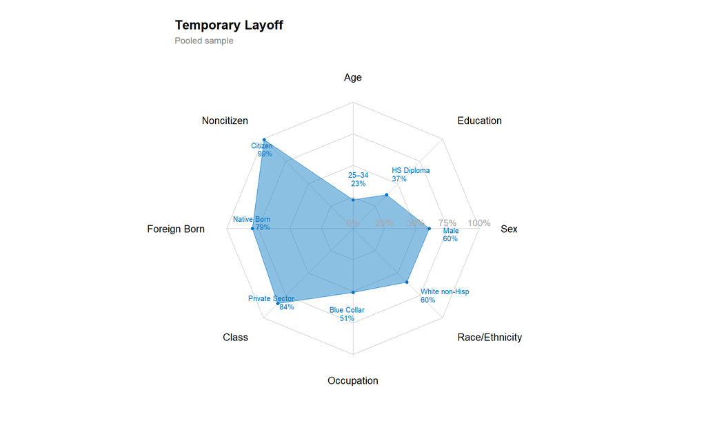

Figure 9: Temporary Layoff dominant-profile radar, pooled sample.

```r
plot_dominant_radar_single(pooled_profiles, "Temporary Layoff", "Pooled sample")
```

**2025 vs. Pooled**

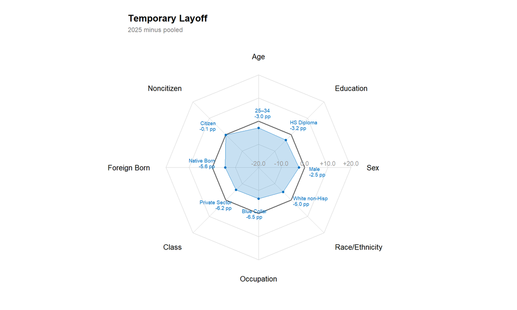

Figure 10: Temporary Layoff dominant-profile radar, 2025 minus pooled share of the same dominant group.

```r
plot_dominant_radar_delta(delta_profiles, "Temporary Layoff", "2025 minus pooled")
```

**Representation Ratio (Pooled)**

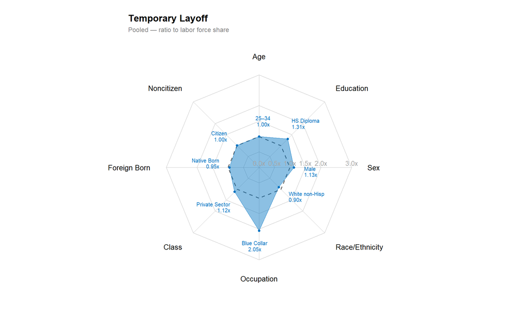

Figure 11: Temporary Layoff representation ratio, pooled sample. Dashed ring = 1.0 (proportional representation).

```r
plot_dominant_radar_ratio(pooled_ratios, "Temporary Layoff", "Pooled — ratio to labor force share")
```

**Representation Ratio (2025 vs. Pooled)**

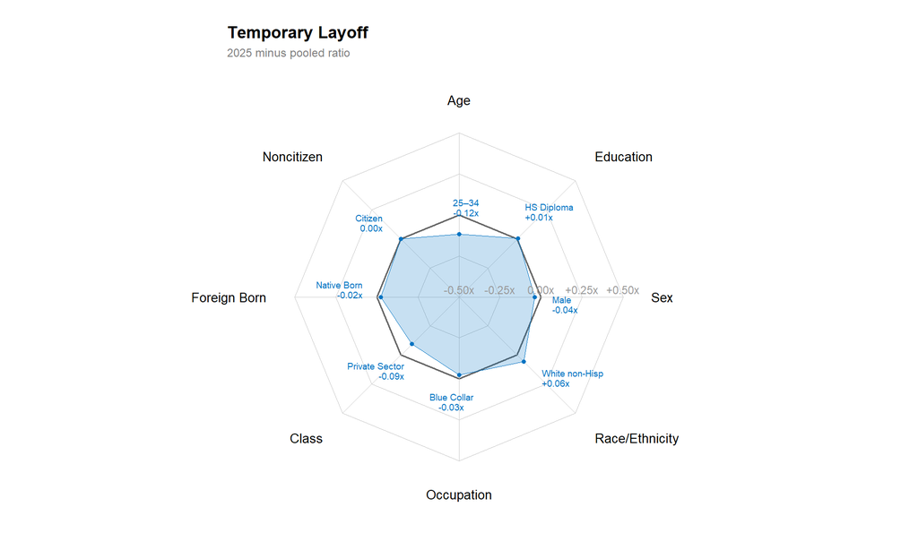

Figure 12: Temporary Layoff representation ratio change, 2025 minus pooled.

```r
plot_dominant_radar_ratio_delta(delta_ratios, "Temporary Layoff", "2025 minus pooled ratio")
```

**Permanent Job Losers**

**Pooled**

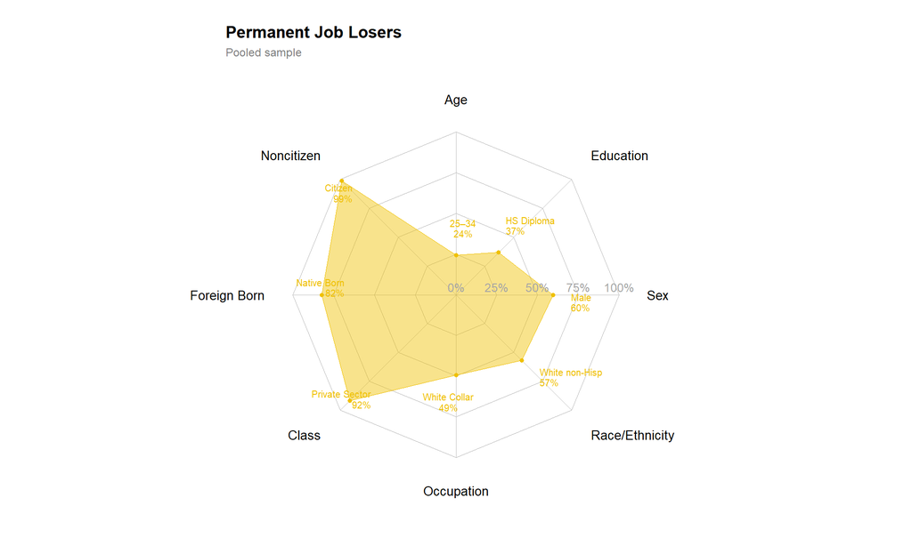

Figure 13: Permanent Job Losers dominant-profile radar, pooled sample.

```r
plot_dominant_radar_single(pooled_profiles, "Permanent Job Losers", "Pooled sample")
```

**2025 vs. Pooled**

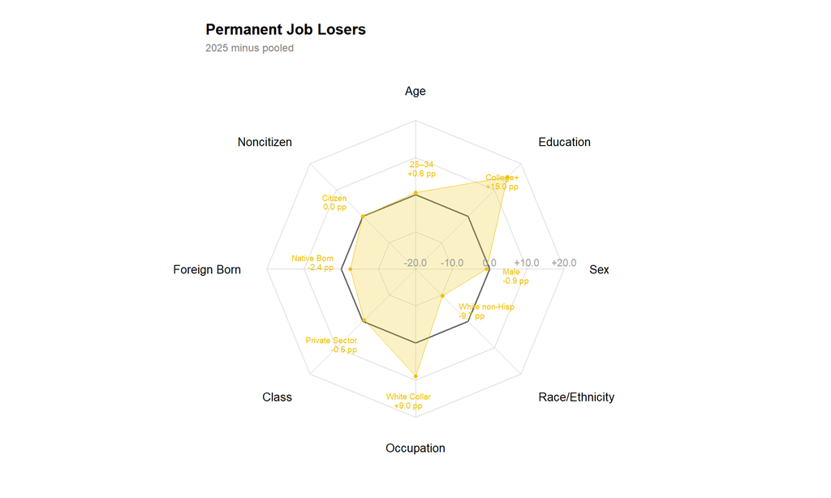

Figure 14: Permanent Job Losers dominant-profile radar, 2025 minus pooled share of the same dominant group.

```r
plot_dominant_radar_delta(delta_profiles, "Permanent Job Losers", "2025 minus pooled")
```

**Representation Ratio (Pooled)**

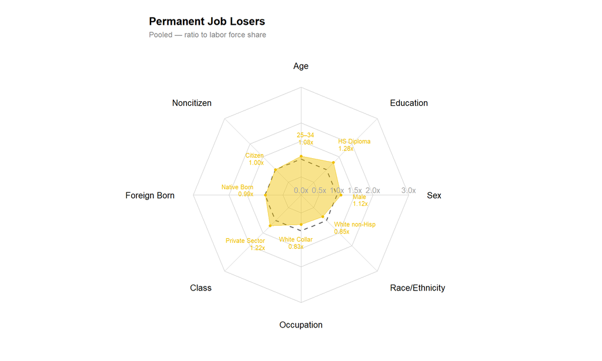

Figure 15: Permanent Job Losers representation ratio, pooled sample. Dashed ring = 1.0 (proportional representation).

```r
plot_dominant_radar_ratio(pooled_ratios, "Permanent Job Losers", "Pooled — ratio to labor force share")
```

**Representation Ratio (2025 vs. Pooled)**

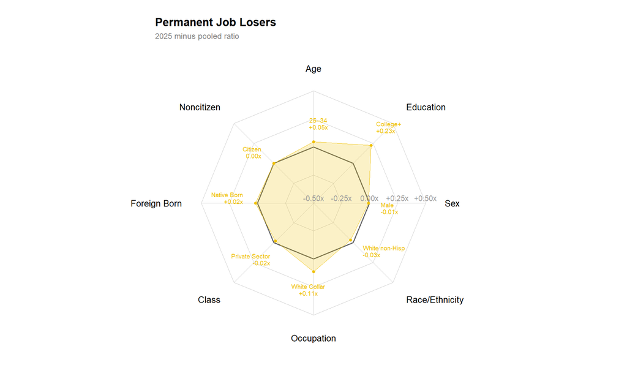

Figure 16: Permanent Job Losers representation ratio change, 2025 minus pooled.

```r
plot_dominant_radar_ratio_delta(delta_ratios, "Permanent Job Losers", "2025 minus pooled ratio")
```

**Reentrants**

**Pooled**

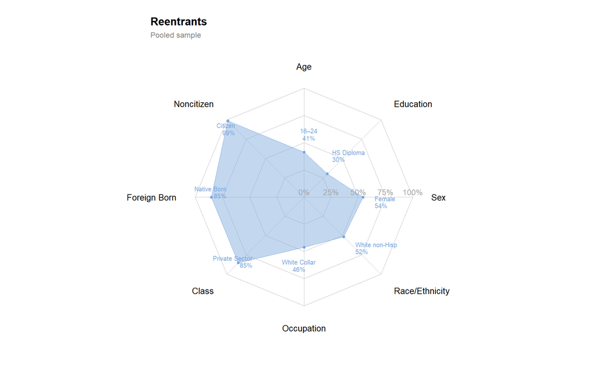

Figure 17: Reentrants dominant-profile radar, pooled sample.

```r
plot_dominant_radar_single(pooled_profiles, "Reentrants", "Pooled sample")
```

**2025 vs. Pooled**

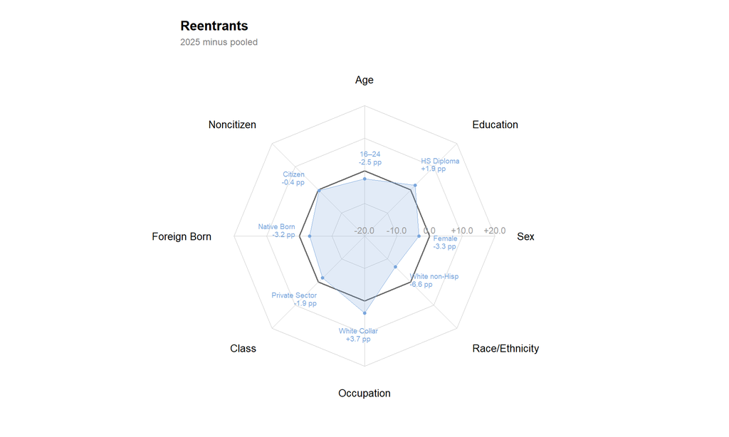

Figure 18: Reentrants dominant-profile radar, 2025 minus pooled share of the same dominant group.

```r
plot_dominant_radar_delta(delta_profiles, "Reentrants", "2025 minus pooled")
```

**Representation Ratio (Pooled)**

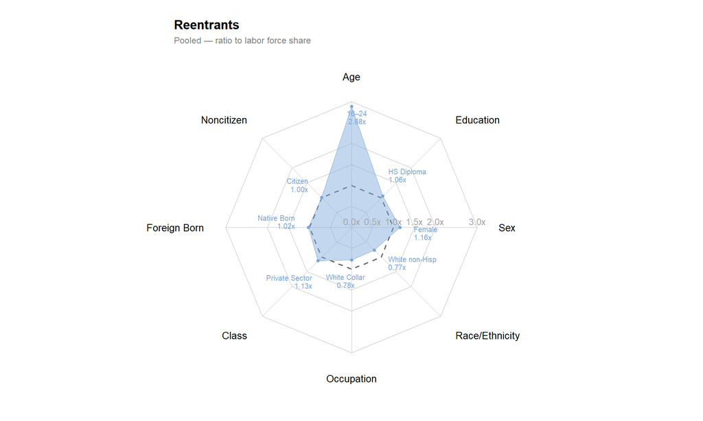

Figure 19: Reentrants representation ratio, pooled sample. Dashed ring = 1.0 (proportional representation).

```r
plot_dominant_radar_ratio(pooled_ratios, "Reentrants", "Pooled — ratio to labor force share")
```

**Representation Ratio (2025 vs. Pooled)**

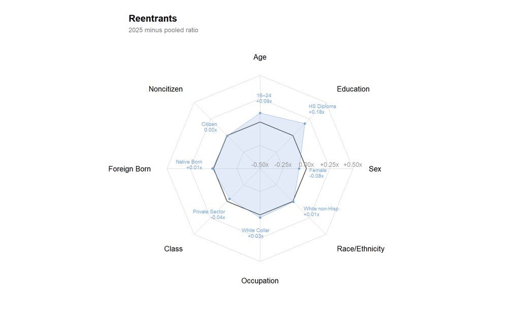

Figure 20: Reentrants representation ratio change, 2025 minus pooled.

```r
plot_dominant_radar_ratio_delta(delta_ratios, "Reentrants", "2025 minus pooled ratio")
```

**New Entrants**

**Pooled**

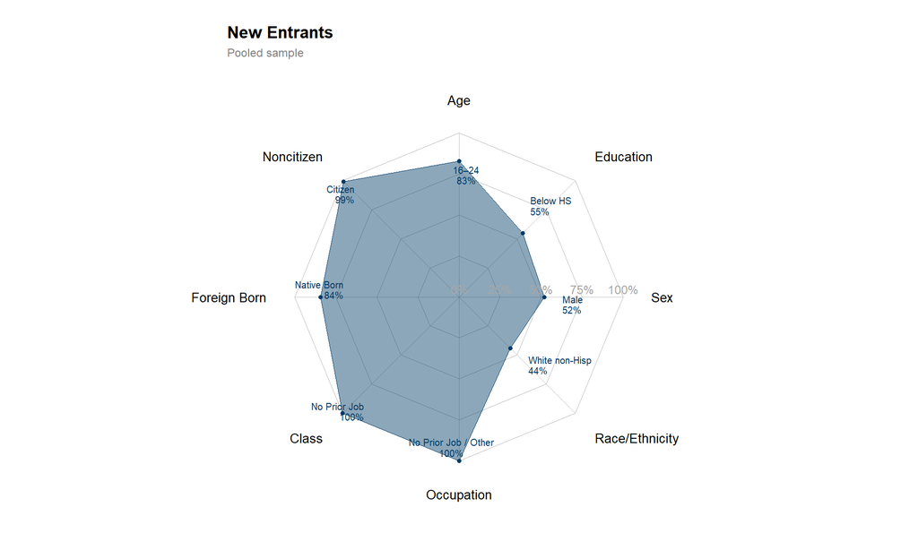

Figure 21: New Entrants dominant-profile radar, pooled sample.

```r
plot_dominant_radar_single(pooled_profiles, "New Entrants", "Pooled sample")
```

**2025 vs. Pooled**

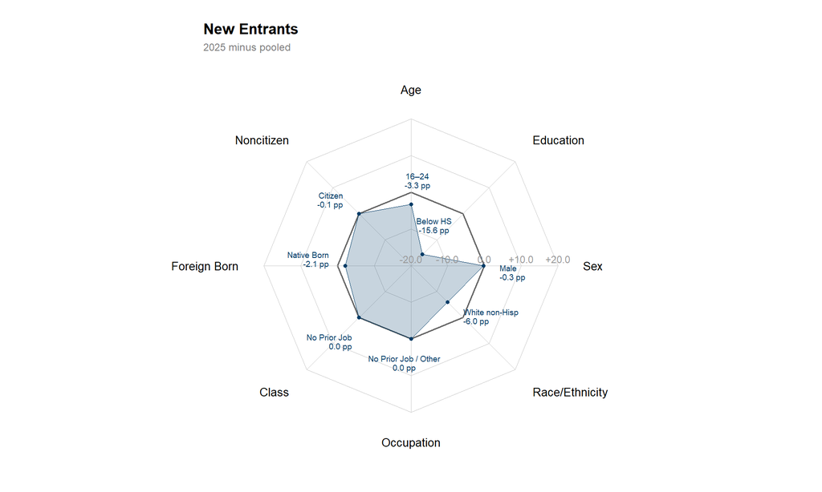

Figure 22: New Entrants dominant-profile radar, 2025 minus pooled share of the same dominant group.

```r
plot_dominant_radar_delta(delta_profiles, "New Entrants", "2025 minus pooled")
```

**Representation Ratio (Pooled)**

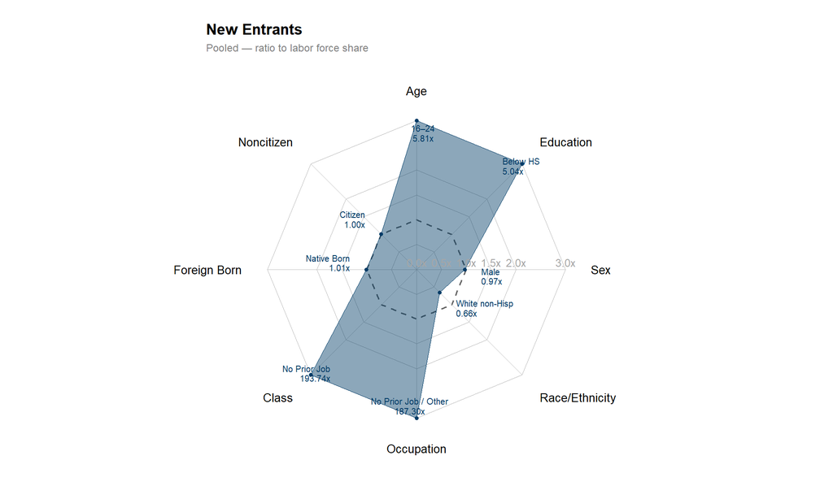

Figure 23: New Entrants representation ratio, pooled sample. Dashed ring = 1.0 (proportional representation).

```r
plot_dominant_radar_ratio(pooled_ratios, "New Entrants", "Pooled — ratio to labor force share")
```

**Representation Ratio (2025 vs. Pooled)**

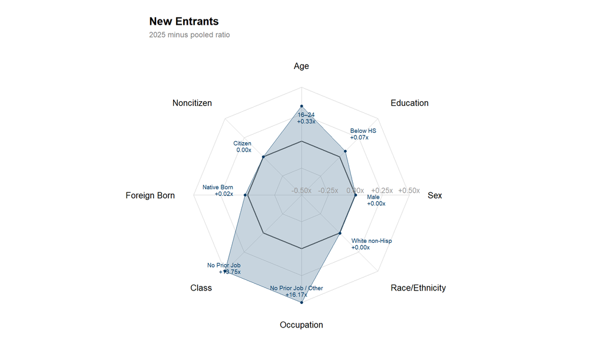

Figure 24: New Entrants representation ratio change, 2025 minus pooled.

```r
plot_dominant_radar_ratio_delta(delta_ratios, "New Entrants", "2025 minus pooled ratio")
```

### Summary of Demographic Profiles

Four patterns stand out across the profile and representation-ratio charts.

Temporary layoffs remain the most clearly UI-attached category, with blue-collar workers overrepresented at roughly 2× their labor force share. Permanent job losers have shifted toward more white-collar and more educated dominant groups, which matters if within-cause filing propensities differ across worker types. Reentrants skew heavily young (16–24) at nearly 3× their labor force share, consistent with intermittent labor force attachment. New entrants remain structurally distant from UI eligibility, but their profile also evolves over time. The representation-ratio deltas show that most of these patterns are stable — the 2025 ratios are close to their pooled values — reinforcing the point that compositional shifts across causes, not within-cause demographic change, are the primary driver of aggregate variation.

## 4.5 Can Continuing Claims Predict the Unemployment Rate?

The preceding sections show that the composition of the unemployment pool — especially the share made up of UI-ineligible new entrants — varies over time and differs from what claims data alone can see. This section asks a direct question: does knowing the new entrant share improve the ability of continuing claims to predict the unemployment rate?

Three models are estimated on monthly national data, excluding the pandemic window (March 2020–December 2021):

1. **Baseline**: $UR_t = \alpha + \beta \cdot (CC/CE)_t + \varepsilon_t$
2. **Augmented**: $UR_t = \alpha + \beta_1 \cdot (CC/CE)_t + \beta_2 \cdot \text{NewEntShare}_t + \beta_3 \cdot (CC/CE)_t \times \text{NewEntShare}_t + \varepsilon_t$
3. **Occupation-augmented**: $UR_t = \alpha + \beta_1 \cdot (CC/CE)_t + \beta_2 \cdot \text{EntrantShare}_t + \beta_3 \cdot \text{WhiteCollarShare}_t + \beta_4 \cdot (CC/CE)_t \times \text{EntrantShare}_t + \beta_5 \cdot (CC/CE)_t \times \text{WhiteCollarShare}_t + \varepsilon_t$

```r
tibble(
  Component = c("Universe", "Included in white collar", "Excluded from white collar"),
  Description = c(
    "Share of unemployed workers whose last recorded occupation falls in a white-collar category. New entrants with no prior job are not counted as white collar.",
    "Management and business, professional occupations, technicians, sales, and administrative support.",
    "Service occupations, farm/forest/fishing, precision production and craft, operators/fabricators, transport/laborers, military, and no-prior-job or other/unclassified cases."
  )
) |>
  gt() |>
  cols_width(
    Component ~ px(190),
    Description ~ px(700)
  ) |>
  tab_options(
    table.font.size = px(11),
    column_labels.font.weight = "bold",
    column_labels.background.color = "#2c3e50"
  ) |>
  tab_style(
    style = cell_text(color = "white"),
    locations = cells_column_labels()
  )
```

Table 2: What the monthly white-collar share captures in the CPS-based unemployment composition data.

| Component | Description |
| --- | --- |
| Universe | Share of unemployed workers whose last recorded occupation falls in a white-collar category. New entrants with no prior job are not counted as white collar. |
| Included in white collar | Management and business, professional occupations, technicians, sales, and administrative support. |
| Excluded from white collar | Service occupations, farm/forest/fishing, precision production and craft, operators/fabricators, transport/laborers, military, and no-prior-job or other/unclassified cases. |

The interaction term in the augmented model allows the slope of CC/CE on the unemployment rate to vary with the composition of the unemployment pool. New entrants are UI-ineligible and invisible to the claims system. When they make up a larger share of the unemployed, the claims system captures a smaller fraction of total unemployment, so the relationship between claims intensity and the unemployment rate shifts: the same unemployment rate is consistent with *lower* CC/CE because a larger share of the unemployed never filed. Equivalently, any given level of CC/CE corresponds to a higher unemployment rate than the baseline — which ignores composition — would predict.

```r
ur_white_collar_monthly <- read_final_parquet("cps_ui_state_month_panel.parquet") |>
  mutate(date = as.Date(date)) |>
  group_by(date) |>
  summarise(
    white_collar_share = weighted.mean(white_collar_share, unemployed_total, na.rm = TRUE),
    .groups = "drop"
  )

ur_df <- takeup_cause_df |>
  left_join(ur_white_collar_monthly, by = "date") |>
  filter(!is.na(urate), !is.na(cc_ce), !is.na(new_entrant_share), !is.na(white_collar_share)) |>
  mutate(
    pandemic = date >= as.Date("2020-03-01") & date <= as.Date("2021-12-01"),
    cc_ce_pct = cc_ce * 100,
    new_entrant_pct = new_entrant_share * 100,
    white_collar_pct = white_collar_share * 100
  )

ur_est <- ur_df |> filter(!pandemic)

ur_mod1 <- lm(urate ~ cc_ce_pct, data = ur_est)
ur_mod2 <- lm(urate ~ cc_ce_pct * new_entrant_pct, data = ur_est)
ur_mod3 <- lm(
  urate ~ cc_ce_pct + new_entrant_pct + white_collar_pct +
    cc_ce_pct:new_entrant_pct + cc_ce_pct:white_collar_pct,
  data = ur_est
)

ur_cc_ce_points <- c(
  low = quantile(ur_est$cc_ce_pct, 0.10, na.rm = TRUE) |> as.numeric(),
  avg = mean(ur_est$cc_ce_pct, na.rm = TRUE),
  high = quantile(ur_est$cc_ce_pct, 0.90, na.rm = TRUE) |> as.numeric()
)
ur_ne_points <- c(
  low = quantile(ur_est$new_entrant_pct, 0.10, na.rm = TRUE) |> as.numeric(),
  avg = mean(ur_est$new_entrant_pct, na.rm = TRUE),
  high = quantile(ur_est$new_entrant_pct, 0.90, na.rm = TRUE) |> as.numeric()
)
ur_wc_points <- c(
  low = quantile(ur_est$white_collar_pct, 0.10, na.rm = TRUE) |> as.numeric(),
  avg = mean(ur_est$white_collar_pct, na.rm = TRUE),
  high = quantile(ur_est$white_collar_pct, 0.90, na.rm = TRUE) |> as.numeric()
)
ur_mod2_coef <- coef(ur_mod2)
ur_mod3_coef <- coef(ur_mod3)

ur_me_cc <- function(new_entrant_pct) {
  unname(ur_mod2_coef["cc_ce_pct"] +
           ur_mod2_coef["cc_ce_pct:new_entrant_pct"] * new_entrant_pct)
}

ur_me_ne <- function(cc_ce_pct) {
  unname(ur_mod2_coef["new_entrant_pct"] +
           ur_mod2_coef["cc_ce_pct:new_entrant_pct"] * cc_ce_pct)
}

ur3_me_cc <- function(new_entrant_pct, white_collar_pct) {
  unname(
    ur_mod3_coef["cc_ce_pct"] +
      ur_mod3_coef["cc_ce_pct:new_entrant_pct"] * new_entrant_pct +
      ur_mod3_coef["cc_ce_pct:white_collar_pct"] * white_collar_pct
  )
}

ur3_me_wc <- function(cc_ce_pct) {
  unname(
    ur_mod3_coef["white_collar_pct"] +
      ur_mod3_coef["cc_ce_pct:white_collar_pct"] * cc_ce_pct
  )
}

ur3_me_ne <- function(cc_ce_pct) {
  unname(
    ur_mod3_coef["new_entrant_pct"] +
      ur_mod3_coef["cc_ce_pct:new_entrant_pct"] * cc_ce_pct
  )
}
```

### Full-Sample Regression Results

**Coefficient Table**

```r
extract_ur_terms <- function(model, model_label) {
  summary(model)$coefficients |>
    as.data.frame() |>
    rownames_to_column("term") |>
    as_tibble() |>
    mutate(
      Model = model_label,
      term = case_when(
        term == "(Intercept)" ~ "Intercept",
        term == "cc_ce_pct" ~ "CC/CE (pp)",
        term == "new_entrant_pct" ~ "New entrant share (pp)",
        term == "white_collar_pct" ~ "White-collar share (pp)",
        term == "cc_ce_pct:new_entrant_pct" ~ "CC/CE × New entrant share",
        term %in% c("cc_ce_pct:white_collar_pct", "white_collar_pct:cc_ce_pct") ~
          "CC/CE × White-collar share",
        TRUE ~ term
      )
    ) |>
    select(Model, Term = term, Estimate, `Std. Error`, `p-value` = `Pr(>|t|)`)
}

bind_rows(
  extract_ur_terms(ur_mod1, "Baseline: UR ~ CC/CE"),
  extract_ur_terms(ur_mod2, "Augmented: UR ~ CC/CE × New entrant share"),
  extract_ur_terms(ur_mod3, "Occupation-augmented: + White-collar share")
) |>
  gt(groupname_col = "Model") |>
  fmt_number(columns = c(Estimate, `Std. Error`), decimals = 3) |>
  fmt_number(columns = `p-value`, decimals = 4) |>
  tab_options(
    table.font.size = px(11),
    column_labels.font.weight = "bold",
    column_labels.background.color = "#2c3e50"
  ) |>
  tab_style(
    style = cell_text(color = "white"),
    locations = cells_column_labels()
  )
```

Table 3: OLS regressions of the unemployment rate (%) on CC/CE (pp) and new entrant share (pp). Coefficients show the predicted change in the unemployment rate for a 1 pp increase in the regressor.

| Term | Estimate | Std. Error | p-value |
| --- | --- | --- | --- |
| Baseline: UR ~ CC/CE |  |  |  |
| Intercept | 1.400 | 0.122 | 0.0000 |
| CC/CE (pp) | 1.948 | 0.055 | 0.0000 |
| Augmented: UR ~ CC/CE × New entrant share |  |  |  |
| Intercept | 1.192 | 0.517 | 0.0217 |
| CC/CE (pp) | 0.119 | 0.222 | 0.5934 |
| New entrant share (pp) | −0.081 | 0.059 | 0.1698 |
| CC/CE × New entrant share | 0.263 | 0.026 | 0.0000 |
| Occupation-augmented: + White-collar share |  |  |  |
| Intercept | −7.567 | 1.071 | 0.0000 |
| CC/CE (pp) | 3.394 | 0.532 | 0.0000 |
| New entrant share (pp) | −0.291 | 0.054 | 0.0000 |
| White-collar share (pp) | 0.255 | 0.026 | 0.0000 |
| CC/CE × New entrant share | 0.357 | 0.024 | 0.0000 |
| CC/CE × White-collar share | −0.098 | 0.013 | 0.0000 |

```r
tibble(
  Model = c("Baseline", "Augmented", "Occupation-augmented"),
  `R²` = c(summary(ur_mod1)$r.squared, summary(ur_mod2)$r.squared, summary(ur_mod3)$r.squared),
  `Adj. R²` = c(summary(ur_mod1)$adj.r.squared, summary(ur_mod2)$adj.r.squared, summary(ur_mod3)$adj.r.squared),
  `RMSE (pp)` = c(
    sqrt(mean(residuals(ur_mod1)^2)),
    sqrt(mean(residuals(ur_mod2)^2)),
    sqrt(mean(residuals(ur_mod3)^2))
  ),
  `Sample Start` = format(min(ur_est$date), "%Y-%m"),
  `Sample End` = format(max(ur_est$date), "%Y-%m"),
  N = nrow(ur_est)
) |>
  gt() |>
  fmt_number(columns = c(`R²`, `Adj. R²`, `RMSE (pp)`), decimals = 3) |>
  tab_options(
    table.font.size = px(11),
    column_labels.font.weight = "bold",
    column_labels.background.color = "#2c3e50"
  ) |>
  tab_style(
    style = cell_text(color = "white"),
    locations = cells_column_labels()
  ) |>
  tab_footnote("Pandemic months (Mar 2020–Dec 2021) excluded from estimation.")
```

Table 4: Model fit for the unemployment rate prediction regressions.

| Model | R² | Adj. R² | RMSE (pp) | Sample Start | Sample End | N |
| --- | --- | --- | --- | --- | --- | --- |
| Baseline | 0.774 | 0.773 | 0.788 | 1994-01 | 2026-02 | 363 |
| Augmented | 0.921 | 0.921 | 0.465 | 1994-01 | 2026-02 | 363 |
| Occupation-augmented | 0.942 | 0.942 | 0.397 | 1994-01 | 2026-02 | 363 |

Pandemic months (Mar 2020–Dec 2021) excluded from estimation.

```r
tibble(
  Variable = c("UR (%)", "CC/CE (pp)", "New entrant share (pp)", "White-collar share (pp)"),
  Mean = c(
    mean(ur_est$urate, na.rm = TRUE),
    ur_cc_ce_points["avg"],
    ur_ne_points["avg"],
    mean(ur_est$white_collar_pct, na.rm = TRUE)
  ),
  P10 = c(
    quantile(ur_est$urate, 0.10, na.rm = TRUE) |> as.numeric(),
    ur_cc_ce_points["low"],
    ur_ne_points["low"],
    quantile(ur_est$white_collar_pct, 0.10, na.rm = TRUE) |> as.numeric()
  ),
  P90 = c(
    quantile(ur_est$urate, 0.90, na.rm = TRUE) |> as.numeric(),
    ur_cc_ce_points["high"],
    ur_ne_points["high"],
    quantile(ur_est$white_collar_pct, 0.90, na.rm = TRUE) |> as.numeric()
  )
) |>
  gt() |>
  fmt_number(columns = c(Mean, P10, P90), decimals = 2) |>
  tab_options(
    table.font.size = px(11),
    column_labels.font.weight = "bold",
    column_labels.background.color = "#2c3e50"
  ) |>
  tab_style(
    style = cell_text(color = "white"),
    locations = cells_column_labels()
  ) |>
  tab_footnote("Computed on the same non-pandemic monthly sample used for the full-sample regressions.")
```

Table 5: Regression-sample values for key regressors used to interpret the interaction and marginal effects.

| Variable | Mean | P10 | P90 |
| --- | --- | --- | --- |
| UR (%) | 5.45 | 3.81 | 8.27 |
| CC/CE (pp) | 2.08 | 1.20 | 2.93 |
| New entrant share (pp) | 8.85 | 7.18 | 10.78 |
| White-collar share (pp) | 39.80 | 35.75 | 43.87 |

Computed on the same non-pandemic monthly sample used for the full-sample regressions.

```r
fmt2 <- function(x) sprintf("%.2f", x)
effect_text <- function(x) {
  direction <- if (x >= 0) "higher" else "lower"
  paste0(fmt2(abs(x)), " pp ", direction)
}

cat(
  "**Interpretation.** Model 2 isolates how the `CC/CE` slope changes with the new entrant share alone. ",
  "For that specification, the slope is ",
  "$\\partial UR / \\partial (CC/CE) = \\beta_1 + \\beta_3 \\cdot \\text{New entrant share}$. ",
  "The marginal effect of the new entrant share is ",
  "$\\partial UR / \\partial \\text{New entrant share} = \\beta_2 + \\beta_3 \\cdot (CC/CE)$.\n\n",
  "- **Model 2, marginal effect of CC/CE across new entrant share scenarios:** When the new entrant share is low (p10 = ",
  fmt2(ur_ne_points["low"]), "%), a 1 pp increase in `CC/CE` is associated with an unemployment rate that is ",
  effect_text(ur_me_cc(ur_ne_points["low"])), ". At the average new entrant share (mean = ",
  fmt2(ur_ne_points["avg"]), "%), the same 1 pp increase in `CC/CE` is associated with an unemployment rate that is ",
  effect_text(ur_me_cc(ur_ne_points["avg"])), ". When the new entrant share is high (p90 = ",
  fmt2(ur_ne_points["high"]), "%), the implied effect is ",
  effect_text(ur_me_cc(ur_ne_points["high"])), ".\n",
  "- **Model 2, marginal effect of new entrant share across claims scenarios:** When `CC/CE` is low (p10 = ",
  fmt2(ur_cc_ce_points["low"]), " pp), a 1 pp increase in the new entrant share is associated with an unemployment rate that is ",
  effect_text(ur_me_ne(ur_cc_ce_points["low"])), ". At average `CC/CE` (mean = ",
  fmt2(ur_cc_ce_points["avg"]), " pp), the same 1 pp increase in the new entrant share is associated with an unemployment rate that is ",
  effect_text(ur_me_ne(ur_cc_ce_points["avg"])), ". When `CC/CE` is high (p90 = ",
  fmt2(ur_cc_ce_points["high"]), " pp), the implied effect is ",
  effect_text(ur_me_ne(ur_cc_ce_points["high"])), ".\n\n",
  "Model 3 adds a second interaction, so the `CC/CE` slope becomes ",
  "$\\partial UR / \\partial (CC/CE) = \\beta_1 + \\beta_4 \\cdot \\text{Entrant share} + \\beta_5 \\cdot \\text{White-collar share}$. ",
  "The entrant share and white-collar share both have their own level effects. ",
  "The entrant-share marginal effect is ",
  "$\\partial UR / \\partial \\text{Entrant share} = \\beta_2 + \\beta_4 \\cdot (CC/CE)$, ",
  "and the white-collar-share marginal effect is ",
  "$\\partial UR / \\partial \\text{White-collar share} = \\beta_3 + \\beta_5 \\cdot (CC/CE)$. ",
  "So both composition margins can shift the unemployment rate directly and can also change how strongly `CC/CE` maps into unemployment.\n\n",
  "- **Model 3, `CC/CE` slope at average white-collar share:** Holding the white-collar share at its mean (",
  fmt2(ur_wc_points["avg"]), "%), a 1 pp increase in `CC/CE` is associated with an unemployment rate that is ",
  effect_text(ur3_me_cc(ur_ne_points["low"], ur_wc_points["avg"])), " when the entrant share is low (p10 = ",
  fmt2(ur_ne_points["low"]), "%), ",
  effect_text(ur3_me_cc(ur_ne_points["avg"], ur_wc_points["avg"])), " at the average entrant share (mean = ",
  fmt2(ur_ne_points["avg"]), "%), and ",
  effect_text(ur3_me_cc(ur_ne_points["high"], ur_wc_points["avg"])), " when the entrant share is high (p90 = ",
  fmt2(ur_ne_points["high"]), "%).\n",
  "- **Model 3, `CC/CE` slope at average entrant share:** Holding the entrant share at its mean (",
  fmt2(ur_ne_points["avg"]), "%), a 1 pp increase in `CC/CE` is associated with an unemployment rate that is ",
  effect_text(ur3_me_cc(ur_ne_points["avg"], ur_wc_points["low"])), " when the white-collar share is low (p10 = ",
  fmt2(ur_wc_points["low"]), "%), ",
  effect_text(ur3_me_cc(ur_ne_points["avg"], ur_wc_points["avg"])), " at the average white-collar share (mean = ",
  fmt2(ur_wc_points["avg"]), "%), and ",
  effect_text(ur3_me_cc(ur_ne_points["avg"], ur_wc_points["high"])), " when the white-collar share is high (p90 = ",
  fmt2(ur_wc_points["high"]), "%).\n",
  "- **Model 3, marginal effect of the white-collar share across claims scenarios:** When `CC/CE` is low (p10 = ",
  fmt2(ur_cc_ce_points["low"]), " pp), a 1 pp increase in the white-collar share is associated with an unemployment rate that is ",
  effect_text(ur3_me_wc(ur_cc_ce_points["low"])), ". At average `CC/CE` (mean = ",
  fmt2(ur_cc_ce_points["avg"]), " pp), the implied effect is ",
  effect_text(ur3_me_wc(ur_cc_ce_points["avg"])), ". When `CC/CE` is high (p90 = ",
  fmt2(ur_cc_ce_points["high"]), " pp), the implied effect is ",
  effect_text(ur3_me_wc(ur_cc_ce_points["high"])), ".\n",
  "- **Model 3, marginal effect of the entrant share across claims scenarios:** When `CC/CE` is low (p10 = ",
  fmt2(ur_cc_ce_points["low"]), " pp), a 1 pp increase in the entrant share is associated with an unemployment rate that is ",
  effect_text(ur3_me_ne(ur_cc_ce_points["low"])), ". At average `CC/CE` (mean = ",
  fmt2(ur_cc_ce_points["avg"]), " pp), the implied effect is ",
  effect_text(ur3_me_ne(ur_cc_ce_points["avg"])), ". When `CC/CE` is high (p90 = ",
  fmt2(ur_cc_ce_points["high"]), " pp), the implied effect is ",
  effect_text(ur3_me_ne(ur_cc_ce_points["high"])), ".\n"
)
```

**Interpretation.** Model 2 isolates how the `CC/CE` slope changes with the new entrant share alone. For that specification, the slope is $\partial UR / \partial (CC/CE) = \beta_1 + \beta_3 \cdot \text{New entrant share}$. The marginal effect of the new entrant share is $\partial UR / \partial \text{New entrant share} = \beta_2 + \beta_3 \cdot (CC/CE)$.

- **Model 2, marginal effect of CC/CE across new entrant share scenarios:** When the new entrant share is low (p10 = 7.18 %), a 1 pp increase in `CC/CE` is associated with an unemployment rate that is 2.01 pp higher . At the average new entrant share (mean = 8.85 %), the same 1 pp increase in `CC/CE` is associated with an unemployment rate that is 2.44 pp higher . When the new entrant share is high (p90 = 10.78 %), the implied effect is 2.95 pp higher .
- **Model 2, marginal effect of new entrant share across claims scenarios:** When `CC/CE` is low (p10 = 1.20 pp), a 1 pp increase in the new entrant share is associated with an unemployment rate that is 0.24 pp higher . At average `CC/CE` (mean = 2.08 pp), the same 1 pp increase in the new entrant share is associated with an unemployment rate that is 0.47 pp higher . When `CC/CE` is high (p90 = 2.93 pp), the implied effect is 0.69 pp higher .

Model 3 adds a second interaction, so the `CC/CE` slope becomes $\partial UR / \partial (CC/CE) = \beta_1 + \beta_4 \cdot \text{Entrant share} + \beta_5 \cdot \text{White-collar share}$. The entrant share and white-collar share both have their own level effects. The entrant-share marginal effect is $\partial UR / \partial \text{Entrant share} = \beta_2 + \beta_4 \cdot (CC/CE)$, and the white-collar-share marginal effect is $\partial UR / \partial \text{White-collar share} = \beta_3 + \beta_5 \cdot (CC/CE)$. So both composition margins can shift the unemployment rate directly and can also change how strongly `CC/CE` maps into unemployment.

- **Model 3, `CC/CE` slope at average white-collar share:** Holding the white-collar share at its mean ( 39.80 %), a 1 pp increase in `CC/CE` is associated with an unemployment rate that is 2.06 pp higher when the entrant share is low (p10 = 7.18 %), 2.65 pp higher at the average entrant share (mean = 8.85 %), and 3.34 pp higher when the entrant share is high (p90 = 10.78 %).
- **Model 3, `CC/CE` slope at average entrant share:** Holding the entrant share at its mean ( 8.85 %), a 1 pp increase in `CC/CE` is associated with an unemployment rate that is 3.05 pp higher when the white-collar share is low (p10 = 35.75 %), 2.65 pp higher at the average white-collar share (mean = 39.80 %), and 2.26 pp higher when the white-collar share is high (p90 = 43.87 %).
- **Model 3, marginal effect of the white-collar share across claims scenarios:** When `CC/CE` is low (p10 = 1.20 pp), a 1 pp increase in the white-collar share is associated with an unemployment rate that is 0.14 pp higher . At average `CC/CE` (mean = 2.08 pp), the implied effect is 0.05 pp higher . When `CC/CE` is high (p90 = 2.93 pp), the implied effect is 0.03 pp lower .
- **Model 3, marginal effect of the entrant share across claims scenarios:** When `CC/CE` is low (p10 = 1.20 pp), a 1 pp increase in the entrant share is associated with an unemployment rate that is 0.14 pp higher . At average `CC/CE` (mean = 2.08 pp), the implied effect is 0.45 pp higher . When `CC/CE` is high (p90 = 2.93 pp), the implied effect is 0.76 pp higher .

**Fitted vs. Actual**

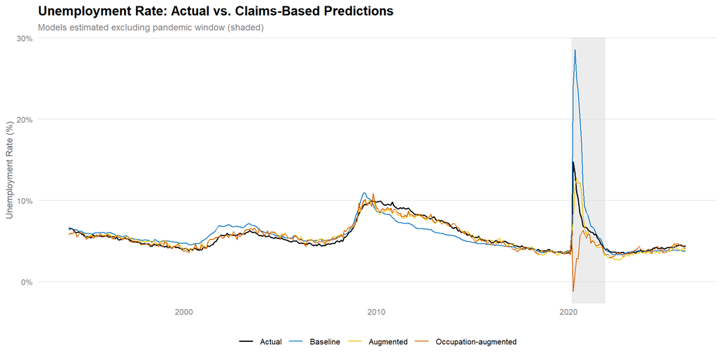

Figure 25: Actual unemployment rate vs. fitted values from the baseline (CC/CE only) and augmented (CC/CE × New Entrant Share) models.

```r
ur_fitted <- ur_df |>
  mutate(
    fitted_baseline = predict(ur_mod1, newdata = ur_df),
    fitted_augmented = predict(ur_mod2, newdata = ur_df),
    fitted_occ_augmented = predict(ur_mod3, newdata = ur_df)
  )

ur_fitted |>
  select(
    date,
    Actual = urate,
    Baseline = fitted_baseline,
    Augmented = fitted_augmented,
    `Occupation-augmented` = fitted_occ_augmented
  ) |>
  pivot_longer(-date, names_to = "series", values_to = "value") |>
  mutate(series = factor(series, levels = c("Actual", "Baseline", "Augmented", "Occupation-augmented"))) |>
  ggplot(aes(date, value, color = series, linewidth = series)) +
  annotate("rect",
           xmin = as.Date("2020-03-01"), xmax = as.Date("2021-12-01"),
           ymin = -Inf, ymax = Inf, fill = "grey85", alpha = 0.5) +
  geom_line() +
  scale_color_manual(values = c(
    Actual = "black",
    Baseline = "#0073C2",
    Augmented = "#EFC000",
    `Occupation-augmented` = "#D55E00"
  )) +
  scale_linewidth_manual(values = c(
    Actual = 0.7,
    Baseline = 0.5,
    Augmented = 0.5,
    `Occupation-augmented` = 0.5
  )) +
  scale_y_continuous(labels = \(x) paste0(x, "%")) +
  labs(title = "Unemployment Rate: Actual vs. Claims-Based Predictions",
       subtitle = "Models estimated excluding pandemic window (shaded)",
       x = NULL, y = "Unemployment Rate (%)", color = NULL, linewidth = NULL) +
  theme_report +
  theme(legend.position = "bottom")
```

**Residuals**

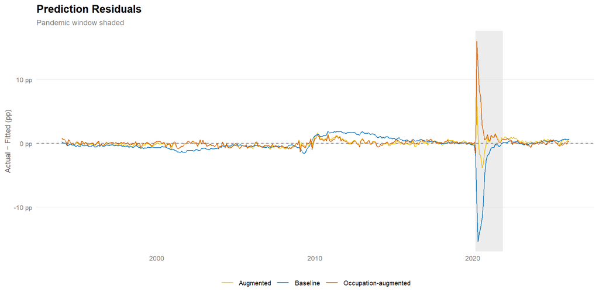

Figure 26: Residuals from the baseline and augmented models. Negative values indicate the actual UR is below the claims-implied level.

```r
ur_fitted |>
  mutate(
    resid_baseline = urate - fitted_baseline,
    resid_augmented = urate - fitted_augmented,
    resid_occ_augmented = urate - fitted_occ_augmented
  ) |>
  select(
    date,
    Baseline = resid_baseline,
    Augmented = resid_augmented,
    `Occupation-augmented` = resid_occ_augmented
  ) |>
  pivot_longer(-date, names_to = "model", values_to = "residual") |>
  ggplot(aes(date, residual, color = model)) +
  annotate("rect",
           xmin = as.Date("2020-03-01"), xmax = as.Date("2021-12-01"),
           ymin = -Inf, ymax = Inf, fill = "grey85", alpha = 0.5) +
  geom_hline(yintercept = 0, linetype = "dashed", color = "grey50") +
  geom_line(linewidth = 0.5) +
  scale_color_manual(values = c(
    Baseline = "#0073C2",
    Augmented = "#EFC000",
    `Occupation-augmented` = "#D55E00"
  )) +
  scale_y_continuous(labels = \(x) paste0(x, " pp")) +
  labs(title = "Prediction Residuals",
       subtitle = "Pandemic window shaded",
       x = NULL, y = "Actual − Fitted (pp)", color = NULL) +
  theme_report +
  theme(legend.position = "bottom")
```

### Pseudo-Out-of-Sample Forecasts

To assess whether these relationships hold up as naive forecasting tools, I estimate an expanding-window pseudo-out-of-sample exercise. For each month $t$, the models are estimated on all non-pandemic data through month $t - 1$ and used to produce a one-step-ahead forecast for month $t$. This mimics what a forecaster would have seen in real time.

```r
min_window <- 60

ur_nopandemic <- ur_df |> filter(!pandemic)
all_dates <- sort(unique(ur_df$date))
train_dates <- sort(unique(ur_nopandemic$date))

oos_results <- map_dfr(seq_along(all_dates), function(i) {
  target_date <- all_dates[i]
  available <- ur_nopandemic |> filter(date < target_date)
  if (nrow(available) < min_window) return(NULL)

  m1 <- lm(urate ~ cc_ce_pct, data = available)
  m2 <- lm(urate ~ cc_ce_pct * new_entrant_pct, data = available)
  m3 <- lm(
    urate ~ cc_ce_pct + new_entrant_pct + white_collar_pct +
      cc_ce_pct:new_entrant_pct + cc_ce_pct:white_collar_pct,
    data = available
  )

  target_row <- ur_df |> filter(date == target_date)
  if (nrow(target_row) == 0) return(NULL)

  tibble(
    date = target_date,
    actual = target_row$urate,
    forecast_baseline = predict(m1, newdata = target_row),
    forecast_augmented = predict(m2, newdata = target_row),
    forecast_occ_augmented = predict(m3, newdata = target_row),
    pandemic = target_row$pandemic
  )
})

oos_nopandemic <- oos_results |> filter(!pandemic)
rmse <- function(a, f) sqrt(mean((a - f)^2, na.rm = TRUE))
mae <- function(a, f) mean(abs(a - f), na.rm = TRUE)

oos_metrics <- tibble(
  Model = c("Baseline", "Augmented", "Occupation-augmented"),
  RMSE = c(
    rmse(oos_nopandemic$actual, oos_nopandemic$forecast_baseline),
    rmse(oos_nopandemic$actual, oos_nopandemic$forecast_augmented),
    rmse(oos_nopandemic$actual, oos_nopandemic$forecast_occ_augmented)
  ),
  MAE = c(
    mae(oos_nopandemic$actual, oos_nopandemic$forecast_baseline),
    mae(oos_nopandemic$actual, oos_nopandemic$forecast_augmented),
    mae(oos_nopandemic$actual, oos_nopandemic$forecast_occ_augmented)
  )
)
```

**Forecast Accuracy**

```r
oos_metrics |>
  rename(`RMSE (pp)` = RMSE, `MAE (pp)` = MAE) |>
  gt() |>
  fmt_number(columns = c(`RMSE (pp)`, `MAE (pp)`), decimals = 2) |>
  tab_footnote(
    paste0("Expanding window with minimum ", min_window, " training months. ",
           "Pandemic months excluded from training and evaluation. Units: percentage points.")
  )
```

Table 6: Pseudo-out-of-sample forecast accuracy (excluding pandemic months from evaluation).

| Model | RMSE (pp) | MAE (pp) |
| --- | --- | --- |
| Baseline | 0.86 | 0.60 |
| Augmented | 0.51 | 0.40 |
| Occupation-augmented | 0.44 | 0.33 |

Expanding window with minimum 60 training months. Pandemic months excluded from training and evaluation. Units: percentage points.

**Forecasts vs. Actual**

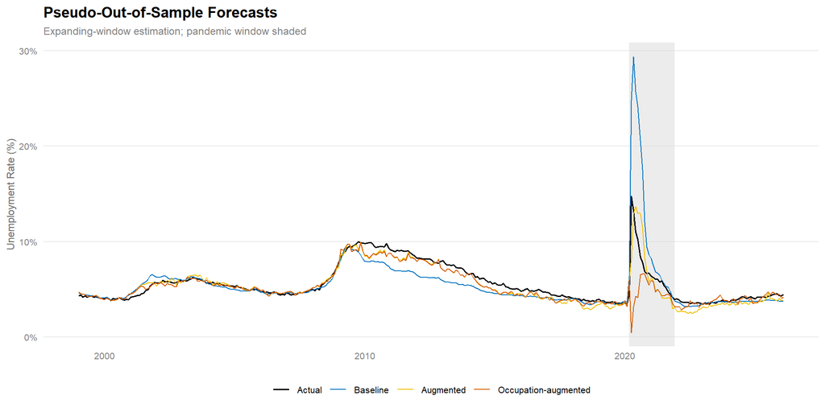

Figure 27: Pseudo-out-of-sample forecasts vs. actual unemployment rate.

```r
oos_results |>
  select(
    date,
    Actual = actual,
    Baseline = forecast_baseline,
    Augmented = forecast_augmented,
    `Occupation-augmented` = forecast_occ_augmented
  ) |>
  pivot_longer(-date, names_to = "series", values_to = "value") |>
  mutate(series = factor(series, levels = c("Actual", "Baseline", "Augmented", "Occupation-augmented"))) |>
  ggplot(aes(date, value, color = series, linewidth = series)) +
  annotate("rect",
           xmin = as.Date("2020-03-01"), xmax = as.Date("2021-12-01"),
           ymin = -Inf, ymax = Inf, fill = "grey85", alpha = 0.5) +
  geom_line() +
  scale_color_manual(values = c(
    Actual = "black",
    Baseline = "#0073C2",
    Augmented = "#EFC000",
    `Occupation-augmented` = "#D55E00"
  )) +
  scale_linewidth_manual(values = c(
    Actual = 0.7,
    Baseline = 0.5,
    Augmented = 0.5,
    `Occupation-augmented` = 0.5
  )) +
  scale_y_continuous(labels = \(x) paste0(x, "%")) +
  labs(title = "Pseudo-Out-of-Sample Forecasts",
       subtitle = "Expanding-window estimation; pandemic window shaded",
       x = NULL, y = "Unemployment Rate (%)", color = NULL, linewidth = NULL) +
  theme_report +
  theme(legend.position = "bottom")
```

**Forecast Errors**

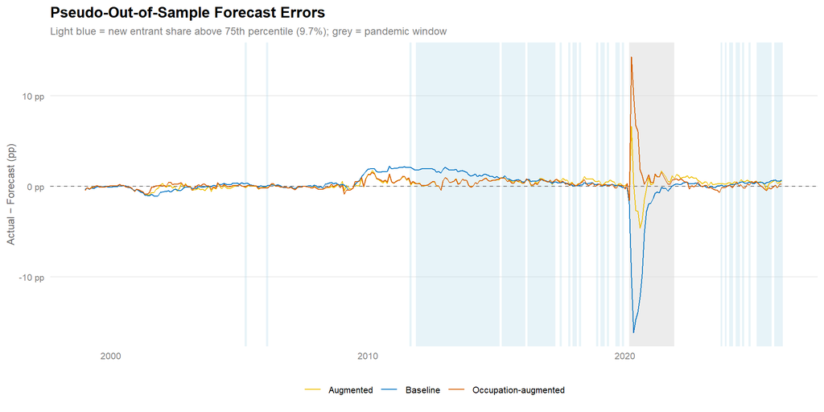

Figure 28: Pseudo-out-of-sample forecast errors (actual minus forecast). Negative values mean the model over-predicted the unemployment rate.

```r
ne_threshold <- quantile(ur_df$new_entrant_pct, 0.75, na.rm = TRUE)

oos_with_ne <- oos_results |>
  left_join(ur_df |> select(date, new_entrant_pct), by = "date") |>
  mutate(high_ne = new_entrant_pct >= ne_threshold)

ne_runs <- oos_with_ne |>
  filter(high_ne) |>
  arrange(date) |>
  mutate(gap = as.numeric(date - lag(date, default = first(date)), units = "days") > 45,
         run = cumsum(gap)) |>
  group_by(run) |>
  summarise(xmin = min(date) - 15, xmax = max(date) + 15, .groups = "drop")

oos_with_ne |>
  mutate(
    err_baseline = actual - forecast_baseline,
    err_augmented = actual - forecast_augmented,
    err_occ_augmented = actual - forecast_occ_augmented
  ) |>
  select(
    date,
    Baseline = err_baseline,
    Augmented = err_augmented,
    `Occupation-augmented` = err_occ_augmented
  ) |>
  pivot_longer(-date, names_to = "model", values_to = "error") |>
  ggplot(aes(date, error, color = model)) +
  geom_rect(data = ne_runs, inherit.aes = FALSE,
            aes(xmin = xmin, xmax = xmax, ymin = -Inf, ymax = Inf),
            fill = "#ADD8E6", alpha = 0.3) +
  annotate("rect",
           xmin = as.Date("2020-03-01"), xmax = as.Date("2021-12-01"),
           ymin = -Inf, ymax = Inf, fill = "grey85", alpha = 0.5) +
  geom_hline(yintercept = 0, linetype = "dashed", color = "grey50") +
  geom_line(linewidth = 0.5) +
  scale_color_manual(values = c(
    Baseline = "#0073C2",
    Augmented = "#EFC000",
    `Occupation-augmented` = "#D55E00"
  )) +
  scale_y_continuous(labels = \(x) paste0(x, " pp")) +
  labs(title = "Pseudo-Out-of-Sample Forecast Errors",
       subtitle = paste0("Light blue = new entrant share above 75th percentile (",
                         sprintf("%.1f", ne_threshold), "%); grey = pandemic window"),
       x = NULL, y = "Actual − Forecast (pp)", color = NULL) +
  theme_report +
  theme(legend.position = "bottom")
```

**Errors by New Entrant Regime**

```r
oos_with_ne |>
  filter(!pandemic) |>
  mutate(
    err_baseline = actual - forecast_baseline,
    err_augmented = actual - forecast_augmented,
    err_occ_augmented = actual - forecast_occ_augmented,
    Period = if_else(high_ne, "High new entrant share", "Normal")
  ) |>
  group_by(Period) |>
  summarise(
    N = n(),
    `Mean Error: Baseline (pp)` = mean(err_baseline),
    `Mean Error: Augmented (pp)` = mean(err_augmented),
    `Mean Error: Occupation-augmented (pp)` = mean(err_occ_augmented),
    `Median Error: Baseline (pp)` = median(err_baseline),
    `Median Error: Augmented (pp)` = median(err_augmented),
    `Median Error: Occupation-augmented (pp)` = median(err_occ_augmented),
    .groups = "drop"
  ) |>
  gt() |>
  fmt_number(columns = where(is.numeric) & !c(N), decimals = 2) |>
  tab_options(
    table.font.size = px(11),
    column_labels.font.weight = "bold",
    column_labels.background.color = "#2c3e50"
  ) |>
  tab_style(
    style = cell_text(color = "white"),
    locations = cells_column_labels()
  ) |>
  tab_footnote(
    paste0("High new entrant share = above 75th percentile (",
           sprintf("%.1f", ne_threshold), "%). ",
           "Positive error = model under-predicted UR; negative = over-predicted.")
  )
```

Table 7: Pseudo-out-of-sample forecast errors by new entrant share regime (excluding pandemic months).

| Period | N | Mean Error: Baseline (pp) | Mean Error: Augmented (pp) | Mean Error: Occupation-augmented (pp) | Median Error: Baseline (pp) | Median Error: Augmented (pp) | Median Error: Occupation-augmented (pp) |
| --- | --- | --- | --- | --- | --- | --- | --- |
| High new entrant share | 97 | 0.91 | 0.42 | 0.33 | 0.70 | 0.45 | 0.32 |
| Normal | 206 | 0.23 | 0.19 | 0.14 | 0.08 | 0.05 | 0.07 |

High new entrant share = above 75th percentile (9.7%). Positive error = model under-predicted UR; negative = over-predicted.

## 4.6 Does the Same Relationship Hold in a State-Year Panel?

Section 4.5 used national monthly time-series variation. This subsection asks the same question in an annual state-year panel, where identification comes from within-state deviations after absorbing persistent cross-state level differences. The key advantage is that the design no longer relies entirely on a single aggregate time series. Relative to a specification with both state and year fixed effects, this version allows the composition variables and claims intensity to account for the aggregate annual time path.

I estimate the same three specifications on the annual state-year panel, excluding 2020 and 2021 from the main estimation sample. The regressions include state fixed effects, annual state-population weights, and standard errors clustered by state:

1. **Baseline**: $UR_{st} = \alpha_s + \beta \cdot (CC/CE)_{st} + \varepsilon_{st}$
2. **Augmented**: $UR_{st} = \alpha_s + \beta_1 \cdot (CC/CE)_{st} + \beta_2 \cdot \text{EntrantShare}_{st} + \beta_3 \cdot (CC/CE)_{st} \times \text{EntrantShare}_{st} + \varepsilon_{st}$
3. **Occupation-augmented**: $UR_{st} = \alpha_s + \beta_1 \cdot (CC/CE)_{st} + \beta_2 \cdot \text{EntrantShare}_{st} + \beta_3 \cdot \text{WhiteCollarShare}_{st} + \beta_4 \cdot (CC/CE)_{st} \times \text{EntrantShare}_{st} + \beta_5 \cdot (CC/CE)_{st} \times \text{WhiteCollarShare}_{st} + \varepsilon_{st}$

The same CPS-based white-collar definition from Section 4.5 is used here.

```r
ur_panel_est <- panel_year |>
  mutate(
    ur_pct = unemployment_rate,
    cc_ce_pct = continued_claims_per_covered_employment * 100,
    new_entrant_pct = new_entrant_share * 100,
    white_collar_pct = white_collar_share * 100
  ) |>
  filter(
    !year %in% c(2020L, 2021L),
    !is.na(ur_pct),
    !is.na(cc_ce_pct),
    !is.na(new_entrant_pct),
    !is.na(white_collar_pct)
  )

urp_mod1 <- feols(
  ur_pct ~ cc_ce_pct | state,
  data = ur_panel_est,
  weights = ~annual_population,
  cluster = ~state
)

urp_mod2 <- feols(
  ur_pct ~ cc_ce_pct * new_entrant_pct | state,
  data = ur_panel_est,
  weights = ~annual_population,
  cluster = ~state
)

urp_mod3 <- feols(
  ur_pct ~ cc_ce_pct + new_entrant_pct + white_collar_pct +
    cc_ce_pct:new_entrant_pct + cc_ce_pct:white_collar_pct | state,
  data = ur_panel_est,
  weights = ~annual_population,
  cluster = ~state
)

urp_cc_ce_points <- c(
  low = quantile(ur_panel_est$cc_ce_pct, 0.10, na.rm = TRUE) |> as.numeric(),
  avg = mean(ur_panel_est$cc_ce_pct, na.rm = TRUE),
  high = quantile(ur_panel_est$cc_ce_pct, 0.90, na.rm = TRUE) |> as.numeric()
)
urp_ne_points <- c(
  low = quantile(ur_panel_est$new_entrant_pct, 0.10, na.rm = TRUE) |> as.numeric(),
  avg = mean(ur_panel_est$new_entrant_pct, na.rm = TRUE),
  high = quantile(ur_panel_est$new_entrant_pct, 0.90, na.rm = TRUE) |> as.numeric()
)
urp_wc_points <- c(
  low = quantile(ur_panel_est$white_collar_pct, 0.10, na.rm = TRUE) |> as.numeric(),
  avg = mean(ur_panel_est$white_collar_pct, na.rm = TRUE),
  high = quantile(ur_panel_est$white_collar_pct, 0.90, na.rm = TRUE) |> as.numeric()
)

urp_mod2_coef <- coef(urp_mod2)
urp_mod3_coef <- coef(urp_mod3)

urp_me_cc <- function(new_entrant_pct) {
  unname(
    urp_mod2_coef["cc_ce_pct"] +
      urp_mod2_coef["cc_ce_pct:new_entrant_pct"] * new_entrant_pct
  )
}

urp_me_ne <- function(cc_ce_pct) {
  unname(
    urp_mod2_coef["new_entrant_pct"] +
      urp_mod2_coef["cc_ce_pct:new_entrant_pct"] * cc_ce_pct
  )
}

urp3_me_cc <- function(new_entrant_pct, white_collar_pct) {
  unname(
    urp_mod3_coef["cc_ce_pct"] +
      urp_mod3_coef["cc_ce_pct:new_entrant_pct"] * new_entrant_pct +
      urp_mod3_coef["cc_ce_pct:white_collar_pct"] * white_collar_pct
  )
}

urp3_me_wc <- function(cc_ce_pct) {
  unname(
    urp_mod3_coef["white_collar_pct"] +
      urp_mod3_coef["cc_ce_pct:white_collar_pct"] * cc_ce_pct
  )
}

urp3_me_ne <- function(cc_ce_pct) {
  unname(
    urp_mod3_coef["new_entrant_pct"] +
      urp_mod3_coef["cc_ce_pct:new_entrant_pct"] * cc_ce_pct
  )
}

panel_fit_stat <- function(model, stat) {
  as.numeric(fitstat(model, stat))
}

ur_panel_pred <- ur_panel_est |>
  mutate(
    fitted_baseline = predict(urp_mod1, newdata = ur_panel_est),
    fitted_augmented = predict(urp_mod2, newdata = ur_panel_est),
    fitted_occ_augmented = predict(urp_mod3, newdata = ur_panel_est)
  )
```

**Coefficients**

```r
extract_urp_terms <- function(model, model_label) {
  coeftable(model) |>
    as.data.frame() |>
    rownames_to_column("term") |>
    as_tibble() |>
    mutate(
      Model = model_label,
      term = case_when(
        term == "cc_ce_pct" ~ "CC/CE (pp)",
        term == "new_entrant_pct" ~ "New entrant share (pp)",
        term == "white_collar_pct" ~ "White-collar share (pp)",
        term == "cc_ce_pct:new_entrant_pct" ~ "CC/CE × New entrant share",
        term %in% c("cc_ce_pct:white_collar_pct", "white_collar_pct:cc_ce_pct") ~
          "CC/CE × White-collar share",
        TRUE ~ term
      )
    ) |>
    select(Model, Term = term, Estimate, `Std. Error`, `p-value` = `Pr(>|t|)`)
}

bind_rows(
  extract_urp_terms(urp_mod1, "Baseline: State FE"),
  extract_urp_terms(urp_mod2, "Augmented: State FE"),
  extract_urp_terms(urp_mod3, "Occupation-augmented: State FE")
) |>
  gt(groupname_col = "Model") |>
  fmt_number(columns = c(Estimate, `Std. Error`), decimals = 3) |>
  fmt_number(columns = `p-value`, decimals = 4) |>
  tab_options(
    table.font.size = px(11),
    column_labels.font.weight = "bold",
    column_labels.background.color = "#2c3e50"
  ) |>
  tab_style(
    style = cell_text(color = "white"),
    locations = cells_column_labels()
  )
```

Table 8: State fixed-effects regressions of the unemployment rate (%) on CC/CE (pp), entrant share (pp), and white-collar share (pp). Estimates use annual state population weights and state-clustered standard errors; 2020 and 2021 are excluded.

| Term | Estimate | Std. Error | p-value |
| --- | --- | --- | --- |
| Baseline: State FE |  |  |  |
| CC/CE (pp) | 1.885 | 0.112 | 0.0000 |
| Augmented: State FE |  |  |  |
| CC/CE (pp) | 0.986 | 0.144 | 0.0000 |
| New entrant share (pp) | −0.060 | 0.037 | 0.1168 |
| CC/CE × New entrant share | 0.116 | 0.021 | 0.0000 |
| Occupation-augmented: State FE |  |  |  |
| CC/CE (pp) | −0.378 | 0.440 | 0.3947 |
| New entrant share (pp) | −0.055 | 0.040 | 0.1748 |
| White-collar share (pp) | −0.022 | 0.018 | 0.2250 |
| CC/CE × New entrant share | 0.121 | 0.021 | 0.0000 |
| CC/CE × White-collar share | 0.034 | 0.009 | 0.0006 |

**Fit And Sample**

```r
tibble(
  Model = c("Baseline: State FE", "Augmented: State FE", "Occupation-augmented: State FE"),
  `Within R²` = c(
    panel_fit_stat(urp_mod1, "wr2"),
    panel_fit_stat(urp_mod2, "wr2"),
    panel_fit_stat(urp_mod3, "wr2")
  ),
  `RMSE (pp)` = c(
    panel_fit_stat(urp_mod1, "rmse"),
    panel_fit_stat(urp_mod2, "rmse"),
    panel_fit_stat(urp_mod3, "rmse")
  ),
  `Sample Start` = min(ur_panel_est$year),
  `Sample End` = max(ur_panel_est$year),
  States = n_distinct(ur_panel_est$state),
  Years = n_distinct(ur_panel_est$year),
  N = nrow(ur_panel_est)
) |>
  gt() |>
  fmt_number(columns = c(`Within R²`, `RMSE (pp)`), decimals = 3) |>
  tab_options(
    table.font.size = px(11),
    column_labels.font.weight = "bold",
    column_labels.background.color = "#2c3e50"
  ) |>
  tab_style(
    style = cell_text(color = "white"),
    locations = cells_column_labels()
  ) |>
  tab_footnote("Fixed-effects regressions with state effects, annual population weights, and state-clustered standard errors.")
```

Table 9: Model fit for the annual state-year unemployment-rate regressions.

| Model | Within R² | RMSE (pp) | Sample Start | Sample End | States | Years | N |
| --- | --- | --- | --- | --- | --- | --- | --- |
| Baseline: State FE | 0.708 | 0.972 | 1994 | 2025 | 50 | 30 | 1500 |
| Augmented: State FE | 0.751 | 0.896 | 1994 | 2025 | 50 | 30 | 1500 |
| Occupation-augmented: State FE | 0.765 | 0.871 | 1994 | 2025 | 50 | 30 | 1500 |

Fixed-effects regressions with state effects, annual population weights, and state-clustered standard errors.

```r
tibble(
  Variable = c("UR (%)", "CC/CE (pp)", "New entrant share (pp)", "White-collar share (pp)"),
  Mean = c(
    mean(ur_panel_est$ur_pct, na.rm = TRUE),
    urp_cc_ce_points["avg"],
    urp_ne_points["avg"],
    urp_wc_points["avg"]
  ),
  P10 = c(
    quantile(ur_panel_est$ur_pct, 0.10, na.rm = TRUE) |> as.numeric(),
    urp_cc_ce_points["low"],
    urp_ne_points["low"],
    urp_wc_points["low"]
  ),
  P90 = c(
    quantile(ur_panel_est$ur_pct, 0.90, na.rm = TRUE) |> as.numeric(),
    urp_cc_ce_points["high"],
    urp_ne_points["high"],
    urp_wc_points["high"]
  )
) |>
  gt() |>
  fmt_number(columns = c(Mean, P10, P90), decimals = 2) |>
  tab_options(
    table.font.size = px(11),
    column_labels.font.weight = "bold",
    column_labels.background.color = "#2c3e50"
  ) |>
  tab_style(
    style = cell_text(color = "white"),
    locations = cells_column_labels()
  ) |>
  tab_footnote("Computed over non-pandemic state-year observations in the estimation sample.")
```

Table 10: Regression-sample values for the annual state-year panel used to interpret the interaction terms.

| Variable | Mean | P10 | P90 |
| --- | --- | --- | --- |
| UR (%) | 5.07 | 3.05 | 7.59 |
| CC/CE (pp) | 1.97 | 0.78 | 3.32 |
| New entrant share (pp) | 8.77 | 5.48 | 12.12 |
| White-collar share (pp) | 38.29 | 30.48 | 45.85 |

Computed over non-pandemic state-year observations in the estimation sample.

**Fitted Vs. Actual**

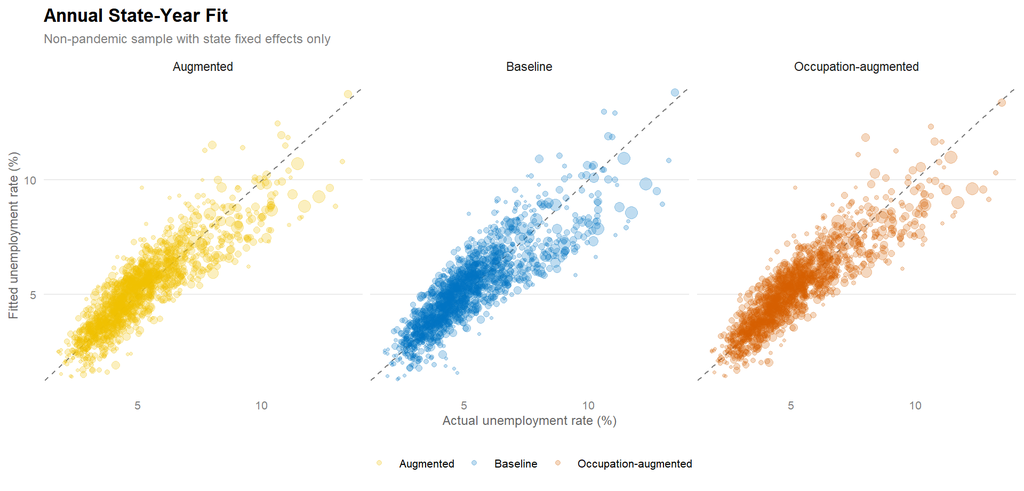

Figure 29: State-year fitted versus actual unemployment rate under state fixed effects only. Each point is a state-year observation; the 45-degree line marks perfect fit.

```r
ur_panel_pred |>
  select(
    ur_pct,
    annual_population,
    Baseline = fitted_baseline,
    Augmented = fitted_augmented,
    `Occupation-augmented` = fitted_occ_augmented
  ) |>
  pivot_longer(c(Baseline, Augmented, `Occupation-augmented`),
               names_to = "model", values_to = "fitted") |>
  ggplot(aes(ur_pct, fitted)) +
  geom_abline(slope = 1, intercept = 0, linetype = "dashed", color = "grey50") +
  geom_point(aes(size = annual_population, color = model), alpha = 0.25) +
  facet_wrap(~model, nrow = 1) +
  scale_color_manual(values = c(
    Baseline = "#0073C2",
    Augmented = "#EFC000",
    `Occupation-augmented` = "#D55E00"
  )) +
  scale_size_continuous(range = c(0.6, 4), guide = "none") +
  labs(
    title = "Annual State-Year Fit",
    subtitle = "Non-pandemic sample with state fixed effects only",
    x = "Actual unemployment rate (%)",
    y = "Fitted unemployment rate (%)",
    color = NULL
  ) +
  theme_report +
  theme(legend.position = "bottom")
```

### Interpretation

```r
fmt2 <- function(x) sprintf("%.2f", x)
effect_text <- function(x) {
  direction <- if (x >= 0) "higher" else "lower"
  paste0(fmt2(abs(x)), " pp ", direction)
}

cat(
  "These coefficients have a different interpretation from the national monthly regressions in Section 4.5. ",
  "Because the models include state fixed effects but not year fixed effects, the variation comes from **within-state deviations around each state's own average level**, while still allowing the regressors to explain the common annual time path. ",
  "So the estimates combine within-state changes over time with aggregate annual movement rather than comparing states only within the same year.\n\n",
  "Relative to the national monthly exercise, the annual panel still confirms the broad entrant-share mechanism, but with weaker fit gains and smaller interaction magnitudes. ",
  "In Section 4.5, the entrant interaction is strongly positive and the model fit rises sharply when entrant share is added. ",
  "Here, the entrant interaction remains positive in both the augmented state-FE model and the occupation-augmented state-FE model, but it is materially smaller than in the national monthly regressions. ",
  "The fit improvement is meaningful but not nearly as dramatic as in Section 4.5. In this subsection, the within $R^2$ rises from ",
  fmt2(panel_fit_stat(urp_mod1, "wr2") * 100), "% in the baseline FE model to ",
  fmt2(panel_fit_stat(urp_mod2, "wr2") * 100), "% in the entrant-augmented FE model and ",
  fmt2(panel_fit_stat(urp_mod3, "wr2") * 100), "% in the occupation-augmented FE model. ",
  "That is much smaller than the national monthly jump in ordinary $R^2$ from ",
  fmt2(summary(ur_mod1)$r.squared * 100), "% to ",
  fmt2(summary(ur_mod2)$r.squared * 100), "% and ",
  fmt2(summary(ur_mod3)$r.squared * 100), "%.\n\n",
  "The comparison therefore suggests that much of the predictive content in Section 4.5 reflects broad national time movement, but not all of it disappears once the analysis shifts to the annual state panel. ",
  "With only state fixed effects, `CC/CE` remains highly predictive, and the entrant interaction continues to point in the expected direction. ",
  "In the national monthly model, white-collar share enters with economically large and statistically precise coefficients. ",
  "In the annual state-year model with state fixed effects only, the `CC/CE × White-collar share` interaction is also positive and statistically significant, which contrasts with the national monthly model where that interaction is negative. ",
  "That sign reversal suggests the white-collar channel is not especially stable across levels of aggregation and identification strategies, so it should be interpreted more cautiously than the entrant interaction. ",
  "The annual state-year results should therefore be read as a bridge between the purely national time-series exercise in Section 4.5 and the more saturated two-way fixed-effects designs later in the paper.\n\n",
  "The state-year marginal effects summarize the size of the relationship directly. ",
  "In the entrant-only state-FE interaction model, a 1 pp increase in `CC/CE` is associated with an unemployment rate that is ",
  effect_text(urp_me_cc(urp_ne_points["low"])), " when the entrant share is low (p10 = ",
  fmt2(urp_ne_points["low"]), "%), ",
  effect_text(urp_me_cc(urp_ne_points["avg"])), " at the average entrant share (mean = ",
  fmt2(urp_ne_points["avg"]), "%), and ",
  effect_text(urp_me_cc(urp_ne_points["high"])), " when the entrant share is high (p90 = ",
  fmt2(urp_ne_points["high"]), "%). ",
  "That slope variation is directionally similar to the national model, but flatter: the entrant interaction here is about 0.12, versus about 0.26 in Section 4.5.\n\n",
  "In the full occupation-augmented state-FE model, holding white-collar share at its mean (",
  fmt2(urp_wc_points["avg"]), "%), a 1 pp increase in `CC/CE` is associated with an unemployment rate that is ",
  effect_text(urp3_me_cc(urp_ne_points["low"], urp_wc_points["avg"])), " when entrant share is low, ",
  effect_text(urp3_me_cc(urp_ne_points["avg"], urp_wc_points["avg"])), " at the average entrant share, and ",
  effect_text(urp3_me_cc(urp_ne_points["high"], urp_wc_points["avg"])), " when entrant share is high. ",
  "Holding entrant share fixed at its mean (", fmt2(urp_ne_points["avg"]), "%), the corresponding `CC/CE` slope moves only from ",
  effect_text(urp3_me_cc(urp_ne_points["avg"], urp_wc_points["low"])), " at low white-collar share to ",
  effect_text(urp3_me_cc(urp_ne_points["avg"], urp_wc_points["high"])), " at high white-collar share. ",
  "The practical reading is that the annual state panel lands between the national monthly model and the stricter two-way FE panel: it keeps the cross-state level adjustment from state fixed effects, but it still lets composition and claims intensity explain the broad annual unemployment path. ",
  "The entrant channel remains robust across those specifications, while the white-collar channel appears more specification-sensitive."
)
```

These coefficients have a different interpretation from the national monthly regressions in Section 4.5. Because the models include state fixed effects but not year fixed effects, the variation comes from **within-state deviations around each state’s own average level**, while still allowing the regressors to explain the common annual time path. So the estimates combine within-state changes over time with aggregate annual movement rather than comparing states only within the same year.

Relative to the national monthly exercise, the annual panel still confirms the broad entrant-share mechanism, but with weaker fit gains and smaller interaction magnitudes. In Section 4.5, the entrant interaction is strongly positive and the model fit rises sharply when entrant share is added. Here, the entrant interaction remains positive in both the augmented state-FE model and the occupation-augmented state-FE model, but it is materially smaller than in the national monthly regressions. The fit improvement is meaningful but not nearly as dramatic as in Section 4.5. In this subsection, the within $R^2$ rises from 70.80 % in the baseline FE model to 75.14 % in the entrant-augmented FE model and 76.54 % in the occupation-augmented FE model. That is much smaller than the national monthly jump in ordinary $R^2$ from 77.39 % to 92.13 % and 94.25 %.

The comparison therefore suggests that much of the predictive content in Section 4.5 reflects broad national time movement, but not all of it disappears once the analysis shifts to the annual state panel. With only state fixed effects, `CC/CE` remains highly predictive, and the entrant interaction continues to point in the expected direction. In the national monthly model, white-collar share enters with economically large and statistically precise coefficients. In the annual state-year model with state fixed effects only, the `CC/CE × White-collar share` interaction is also positive and statistically significant, which contrasts with the national monthly model where that interaction is negative. That sign reversal suggests the white-collar channel is not especially stable across levels of aggregation and identification strategies, so it should be interpreted more cautiously than the entrant interaction. The annual state-year results should therefore be read as a bridge between the purely national time-series exercise in Section 4.5 and the more saturated two-way fixed-effects designs later in the paper.

The state-year marginal effects summarize the size of the relationship directly. In the entrant-only state-FE interaction model, a 1 pp increase in `CC/CE` is associated with an unemployment rate that is 1.62 pp higher when the entrant share is low (p10 = 5.48 %), 2.01 pp higher at the average entrant share (mean = 8.77 %), and 2.40 pp higher when the entrant share is high (p90 = 12.12 %). That slope variation is directionally similar to the national model, but flatter: the entrant interaction here is about 0.12, versus about 0.26 in Section 4.5.

In the full occupation-augmented state-FE model, holding white-collar share at its mean ( 38.29 %), a 1 pp increase in `CC/CE` is associated with an unemployment rate that is 1.61 pp higher when entrant share is low, 2.01 pp higher at the average entrant share, and 2.42 pp higher when entrant share is high. Holding entrant share fixed at its mean ( 8.77 %), the corresponding `CC/CE` slope moves only from 1.74 pp higher at low white-collar share to 2.27 pp higher at high white-collar share. The practical reading is that the annual state panel lands between the national monthly model and the stricter two-way FE panel: it keeps the cross-state level adjustment from state fixed effects, but it still lets composition and claims intensity explain the broad annual unemployment path. The entrant channel remains robust across those specifications, while the white-collar channel appears more specification-sensitive.

### Direct Comparison Table

```r
comparison_models <- list(
  "Base." = ur_mod1,
  "Aug." = ur_mod2,
  "Occ." = ur_mod3,
  "Base. " = urp_mod1,
  "Aug. " = urp_mod2,
  "Occ. " = urp_mod3
)

comparison_gof <- tribble(
  ~raw, ~clean, ~fmt,
  "nobs", "N", 0,
  "r.squared", "R²", 3,
  "within.r.squared", "Within R²", 3,
  "rmse", "RMSE (pp)", 3
)

msummary(
  comparison_models,
  coef_map = c(
    "(Intercept)" = "Intercept",
    "cc_ce_pct" = "CC/CE (pp)",
    "new_entrant_pct" = "New entrant share (pp)",
    "white_collar_pct" = "White-collar share (pp)",
    "cc_ce_pct:new_entrant_pct" = "CC/CE × New entrant share",
    "cc_ce_pct:white_collar_pct" = "CC/CE × White-collar share"
  ),
  gof_map = comparison_gof,
  stars = c("*" = 0.10, "**" = 0.05, "***" = 0.01),
  output = "gt"
) |>
  tab_spanner(label = "National Monthly (Section 4.5)", columns = 2:4) |>
  tab_spanner(label = "State-Year Panel, State FE (Section 4.6)", columns = 5:7) |>
  tab_options(
    table.font.size = px(11),
    column_labels.font.weight = "bold",
    column_labels.background.color = "#2c3e50"
  ) |>
  tab_style(
    style = cell_text(color = "white"),
    locations = cells_column_labels()
  ) |>
  tab_source_note(
    md("National monthly models are OLS on the non-pandemic monthly sample (March 2020 to December 2021 excluded). State-year models use annual population weights, state-clustered standard errors, state fixed effects, and exclude 2020 and 2021.")
  )
```

Table 11: Direct comparison of the national monthly and annual state-year unemployment-rate regressions.

|  | National Monthly (Section 4.5) Base. | National Monthly (Section 4.5) Aug. | National Monthly (Section 4.5) Occ. | State-Year Panel, State FE (Section 4.6) Base. | State-Year Panel, State FE (Section 4.6) Aug. | State-Year Panel, State FE (Section 4.6) Occ. |
| --- | --- | --- | --- | --- | --- | --- |
| Intercept | 1.400*** | 1.192** | -7.567*** |  |  |  |
|  | (0.122) | (0.517) | (1.071) |  |  |  |
| CC/CE (pp) | 1.948*** | 0.119 | 3.394*** | 1.885*** | 0.986*** | -0.378 |
|  | (0.055) | (0.222) | (0.532) | (0.112) | (0.144) | (0.440) |
| New entrant share (pp) |  | -0.081 | -0.291*** |  | -0.060 | -0.055 |
|  |  | (0.059) | (0.054) |  | (0.037) | (0.040) |
| White-collar share (pp) |  |  | 0.255*** |  |  | -0.022 |
|  |  |  | (0.026) |  |  | (0.018) |
| CC/CE × New entrant share |  | 0.263*** | 0.357*** |  | 0.116*** | 0.121*** |
|  |  | (0.026) | (0.024) |  | (0.021) | (0.021) |
| CC/CE × White-collar share |  |  | -0.098*** |  |  | 0.034*** |
|  |  |  | (0.013) |  |  | (0.009) |
| N | 363 | 363 | 363 | 1500 | 1500 | 1500 |
| R² | 0.774 | 0.921 | 0.942 | 0.752 | 0.789 | 0.801 |
| RMSE (pp) | 0.788 | 0.465 | 0.397 | 0.945 | 0.880 | 0.855 |

* p < 0.1, ** p < 0.05, *** p < 0.01  
National monthly models are OLS on the non-pandemic monthly sample (March 2020 to December 2021 excluded). State-year models use annual population weights, state-clustered standard errors, state fixed effects, and exclude 2020 and 2021.

# 5. Data and Measurement

The empirical analysis combines administrative UI claims series with CPS-based unemployment-composition measures in a common benchmarking framework.

## 5.1 UI Claims Data

Administrative UI claims data come from the project’s FRED-based claims pipeline, now stored in local derived outputs rather than pulled ad hoc at render time. For each state, the underlying workflow tracks:

- Initial claims: sum of weekly first-time UI claims within each calendar month
- Continued claims: average weekly continued claims within each calendar month
- Covered employment: the insured job base used to normalize claims

The two outcome variables are:

$$\text{CC/CE}_{st} = \frac{\text{Continued Claims}_{st}}{\text{Covered Employment}_{st}}, \qquad
\text{IC/CE}_{st} = \frac{\text{Initial Claims}_{st}}{\text{Covered Employment}_{st}}$$

These are intensity measures, not take-up rates. They condition on covered employment, the universe of jobs covered by state UI programs, rather than on the number of eligible unemployed. CC/CE is mechanically equivalent to the insured unemployment rate expressed as a share.

## 5.2 Unemployment Composition Data

The unemployment-composition measures are based on CPS reason-for-unemployment categories. In the updated workflow, those measures are read from the project’s derived parquet outputs rather than recomputed from raw CPS microdata during report rendering. For each geography-period, the analysis uses weighted shares of the unemployed falling into the six BLS reason-for-unemployment categories defined in Table 1. The broader project also carries additional composition measures, such as noncitizen share, white-collar share, blue-collar share, and prime-working-age share, though the benchmark here focuses on the by-cause structure.

## 5.3 Panel Construction

The state panels are available at monthly, quarterly, and annual frequency in the local derived-data pipeline. CPS composition measures are noisier at monthly frequency because state-month cells can be thin, particularly in smaller states. Aggregating from monthly to quarterly or annual raises effective sample sizes and reduces sampling noise. The annual panel is therefore the most stable benchmark for the state FE exercises, though it sacrifices short-run time variation.

## 5.4 Limitations

The benchmark is intentionally reduced form. The composition regressors are measured from survey-based unemployment categories rather than administrative eligibility records, so the design does not separately identify eligibility, filing behavior, or administrative barriers. Classical measurement error in the survey-based composition measures will tend to attenuate slope estimates toward zero, with attenuation most severe at higher-frequency and smaller-cell levels of aggregation.

The pandemic period, especially March 2020 through December 2021, involved extraordinary temporary UI programs, eligibility expansions, and administrative disruption. Those episodes temporarily broke the normal historical mapping between unemployment mix and claims intensity, which is why the report repeatedly compares full-sample estimates with pandemic-exclusion variants.

# 6. Data Preparation

```r
national_foreign_born <- nativity_shares |>
  filter(panel == "share_of_total_unemployed", series == "Foreign Born") |>
  transmute(date, foreign_born_share = share / 100)

national_fb_two_group <- nativity_shares |>
  filter(
    panel == "share_of_total_unemployed",
    series %in% c("LF Entrants × FB", "Job Separators × FB")
  ) |>
  transmute(
    date,
    series,
    share = share / 100
  ) |>
  pivot_wider(
    names_from = series,
    values_from = share
  ) |>
  rename(
    foreign_born_entrant_share = `LF Entrants × FB`,
    foreign_born_separator_share = `Job Separators × FB`
  )

takeup_cause_df <- takeup_cause_df |>
  left_join(national_foreign_born, by = "date") |>
  left_join(national_fb_two_group, by = "date") |>
  mutate(
    year = year(date),
    labor_market_entrant_share = reentrant_share + new_entrant_share,
    job_separator_share = temp_layoff_share + perm_job_loser_share +
      completed_temp_job_share + job_leaver_share,
    native_entrant_share = labor_market_entrant_share - foreign_born_entrant_share,
    native_separator_share = job_separator_share - foreign_born_separator_share
  )

national_annual <- takeup_cause_df |>
  group_by(year) |>
  summarise(
    date = as.Date(paste0(first(year), "-01-01")),
    cc_ce = mean(cc_ce, na.rm = TRUE),
    ic_ce = mean(ic_ce, na.rm = TRUE),
    urate = mean(urate, na.rm = TRUE),
    temp_layoff_share = mean(temp_layoff_share, na.rm = TRUE),
    perm_job_loser_share = mean(perm_job_loser_share, na.rm = TRUE),
    completed_temp_job_share = mean(completed_temp_job_share, na.rm = TRUE),
    job_leaver_share = mean(job_leaver_share, na.rm = TRUE),
    reentrant_share = mean(reentrant_share, na.rm = TRUE),
    new_entrant_share = mean(new_entrant_share, na.rm = TRUE),
    .groups = "drop"
  )

fit_national_composition <- function(outcome) {
  lm(as.formula(paste0(
    outcome,
    " ~ temp_layoff_share + perm_job_loser_share + job_leaver_share + reentrant_share + new_entrant_share + month_of_year"
  )), data = takeup_cause_df)
}

cc_cause_model <- fit_national_composition("cc_ce")
ic_cause_model <- fit_national_composition("ic_ce")
takeup_cause_fitted <- takeup_cause_df |>
  mutate(
    cc_ce_hat = predict(cc_cause_model, newdata = takeup_cause_df),
    ic_ce_hat = predict(ic_cause_model, newdata = takeup_cause_df),
    cc_gap = cc_ce - cc_ce_hat,
    ic_gap = ic_ce - ic_ce_hat
  )

fit_national_two_group <- function(outcome) {
  lm(as.formula(paste0(
    outcome,
    " ~ labor_market_entrant_share + month_of_year"
  )), data = takeup_cause_df)
}

cc_two_group_model <- fit_national_two_group("cc_ce")
ic_two_group_model <- fit_national_two_group("ic_ce")
takeup_two_group_fitted <- takeup_cause_df |>
  mutate(
    cc_ce_hat = predict(cc_two_group_model, newdata = takeup_cause_df),
    ic_ce_hat = predict(ic_two_group_model, newdata = takeup_cause_df),
    cc_gap = cc_ce - cc_ce_hat,
    ic_gap = ic_ce - ic_ce_hat
  )

fit_national_two_group_interaction <- function(outcome) {
  lm(as.formula(paste0(
    outcome,
    " ~ native_entrant_share + foreign_born_entrant_share + foreign_born_separator_share + month_of_year"
  )), data = takeup_cause_df)
}

cc_two_group_interaction_model <- fit_national_two_group_interaction("cc_ce")
ic_two_group_interaction_model <- fit_national_two_group_interaction("ic_ce")
takeup_two_group_interaction_fitted <- takeup_cause_df |>
  mutate(
    cc_ce_hat = predict(cc_two_group_interaction_model, newdata = takeup_cause_df),
    ic_ce_hat = predict(ic_two_group_interaction_model, newdata = takeup_cause_df),
    cc_gap = cc_ce - cc_ce_hat,
    ic_gap = ic_ce - ic_ce_hat
  )
```

# 7. Results

## 7.1 National Monthly Composition Regressions

As a descriptive starting point, I estimate national monthly regressions of claims intensity on by-cause unemployment shares with month-of-year fixed effects. Completed temporary jobs are the omitted reference category, because outside the pandemic period this group’s share is close to neutral in the correlation diagnostics from Section 4.

$$y_t = \alpha + \sum_{c \neq \text{CTJ}} \beta_c \, s_{ct} + \sum_{m=2}^{12} \gamma_m \mathbf{1}\{\text{month}(t) = m\} + \varepsilon_t$$

where $y_t \in \{CC/CE_t, IC/CE_t\}$ and $s_{ct}$ is the national share of cause $c$ in month $t$.

```r
extract_share_terms <- function(model, outcome_label) {
  summary(model)$coefficients |>
    as.data.frame() |>
    rownames_to_column("term") |>
    as_tibble() |>
    filter(term %in% c("temp_layoff_share", "perm_job_loser_share", "job_leaver_share", "reentrant_share", "new_entrant_share")) |>
    mutate(
      Outcome = outcome_label,
      term = recode(
        term,
        temp_layoff_share = "Temporary layoff share",
        perm_job_loser_share = "Permanent job-loser share",
        job_leaver_share = "Job leaver share",
        reentrant_share = "Reentrant share",
        new_entrant_share = "New entrant share"
      ),
      `Coef (10 pp shift)` = Estimate * 0.10,
      `Std. Error` = `Std. Error` * 0.10
    ) |>
    select(Outcome, Term = term, `Coef (10 pp shift)`, `Std. Error`, `p-value` = `Pr(>|t|)`)
}

bind_rows(extract_share_terms(cc_cause_model, "CC / CE"),
          extract_share_terms(ic_cause_model, "IC / CE")) |>
  gt(groupname_col = "Outcome") |>
  fmt_number(columns = c(`Coef (10 pp shift)`, `Std. Error`, `p-value`), decimals = 3) |>
  tab_options(
    table.font.size = px(11),
    column_labels.font.weight = "bold",
    column_labels.background.color = "#2c3e50"
  ) |>
  tab_style(
    style = cell_text(color = "white"),
    locations = cells_column_labels()
  )
```

National monthly regressions of claims intensity on by-cause unemployment shares. Completed temporary jobs are the omitted reference category; coefficients are scaled to a 10 percentage-point shift in share.

| Term | Coef (10 pp shift) | Std. Error | p-value |
| --- | --- | --- | --- |
| CC / CE |  |  |  |
| Temporary layoff share | 0.013 | 0.003 | 0.000 |
| Permanent job-loser share | 0.004 | 0.003 | 0.254 |
| Job leaver share | −0.027 | 0.003 | 0.000 |
| Reentrant share | 0.001 | 0.003 | 0.640 |
| New entrant share | −0.014 | 0.004 | 0.000 |
| IC / CE |  |  |  |
| Temporary layoff share | 0.007 | 0.003 | 0.021 |
| Permanent job-loser share | −0.002 | 0.003 | 0.540 |
| Job leaver share | −0.016 | 0.003 | 0.000 |
| Reentrant share | −0.001 | 0.003 | 0.808 |
| New entrant share | −0.009 | 0.004 | 0.023 |

```r
tibble(
  Outcome = c("CC / CE", "IC / CE"),
  `R-squared` = c(summary(cc_cause_model)$r.squared, summary(ic_cause_model)$r.squared),
  RMSE = c(
    sqrt(mean(residuals(cc_cause_model)^2, na.rm = TRUE)),
    sqrt(mean(residuals(ic_cause_model)^2, na.rm = TRUE))
  ),
  `Sample Start` = min(takeup_cause_df$date),
  `Sample End` = max(takeup_cause_df$date)
) |>
  mutate(
    `Sample Start` = format(`Sample Start`, "%Y-%m"),
    `Sample End` = format(`Sample End`, "%Y-%m")
  ) |>
  gt() |>
  fmt_number(columns = c(`R-squared`, RMSE), decimals = 3) |>
  tab_options(
    table.font.size = px(11),
    column_labels.font.weight = "bold",
    column_labels.background.color = "#2c3e50"
  ) |>
  tab_style(
    style = cell_text(color = "white"),
    locations = cells_column_labels()
  )
```

Model fit for the national composition regressions.

| Outcome | R-squared | RMSE | Sample Start | Sample End |
| --- | --- | --- | --- | --- |
| CC / CE | 0.899 | 0.004 | 1994-01 | 2026-03 |
| IC / CE | 0.739 | 0.004 | 1994-01 | 2026-03 |

The national monthly regressions confirm that by-cause unemployment composition carries substantial explanatory power for claims intensity. The CC/CE model explains a very large share of monthly variation, and the IC/CE model also fits strongly. The most intuitive coefficient pattern survives clearly: higher job-leaver and new-entrant shares are associated with lower claims intensity, while temporary layoffs load positively. That is exactly what the benchmark should capture if it is picking up claimant relevance rather than merely generic cycle conditions.

## 7.2 National Observed vs. Predicted Claims Intensity

The fitted values from the national composition model provide a first-pass benchmark: the claims intensity that the by-cause mix and seasonality would predict, versus what is actually observed.

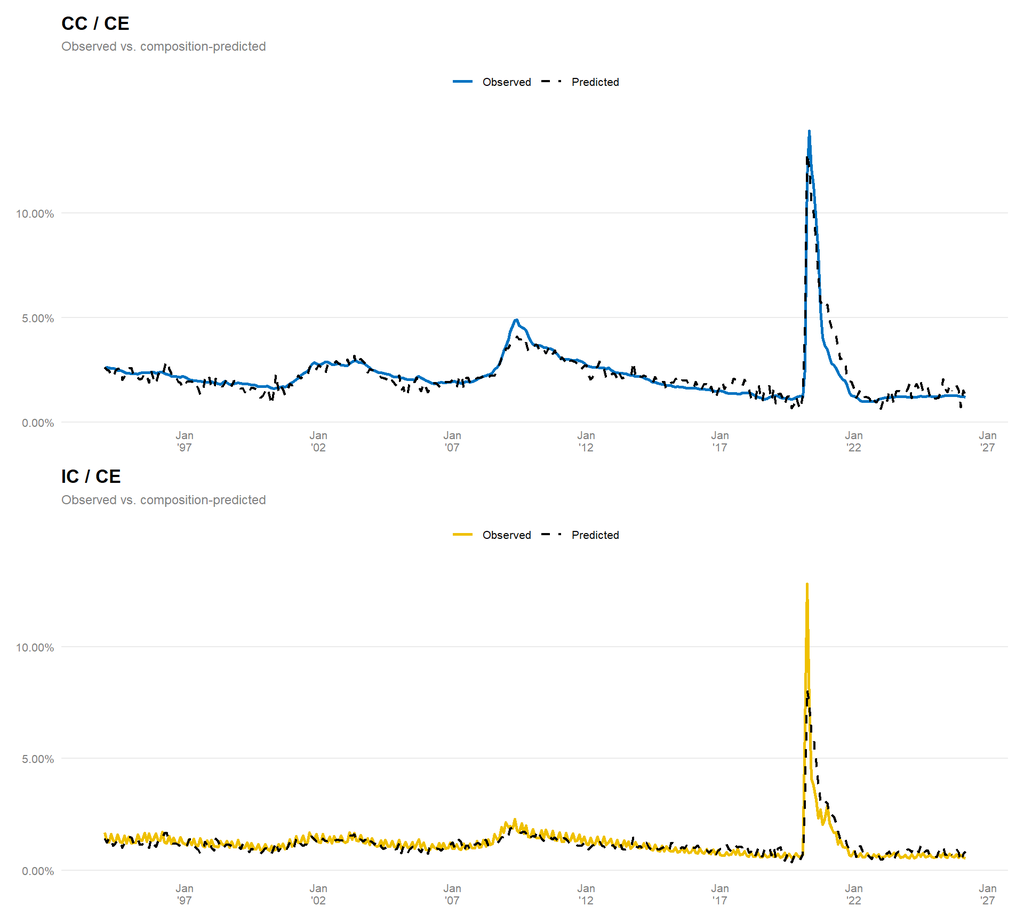

Figure 30: Observed versus composition-predicted national claims intensity, full monthly sample from 1994 onward.

```r
(ggplot(takeup_cause_fitted, aes(date)) +
   geom_line(aes(y = cc_ce, color = "Observed"), linewidth = 0.9) +
   geom_line(aes(y = cc_ce_hat, color = "Predicted"), linewidth = 0.8, linetype = "dashed") +
   scale_color_manual(values = c("Observed" = "#0073C2", "Predicted" = "black")) +
   scale_x_date(date_breaks = "5 years", date_labels = "%b\n'%y") +
   scale_y_continuous(labels = percent_format(accuracy = 0.01)) +
   labs(title = "CC / CE", subtitle = "Observed vs. composition-predicted", x = NULL, y = NULL)) /
  (ggplot(takeup_cause_fitted, aes(date)) +
     geom_line(aes(y = ic_ce, color = "Observed"), linewidth = 0.9) +
     geom_line(aes(y = ic_ce_hat, color = "Predicted"), linewidth = 0.8, linetype = "dashed") +
     scale_color_manual(values = c("Observed" = "#EFC000", "Predicted" = "black")) +
     scale_x_date(date_breaks = "5 years", date_labels = "%b\n'%y") +
     scale_y_continuous(labels = percent_format(accuracy = 0.01)) +
     labs(title = "IC / CE", subtitle = "Observed vs. composition-predicted", x = NULL, y = NULL)) &
  theme(legend.position = "top")
```

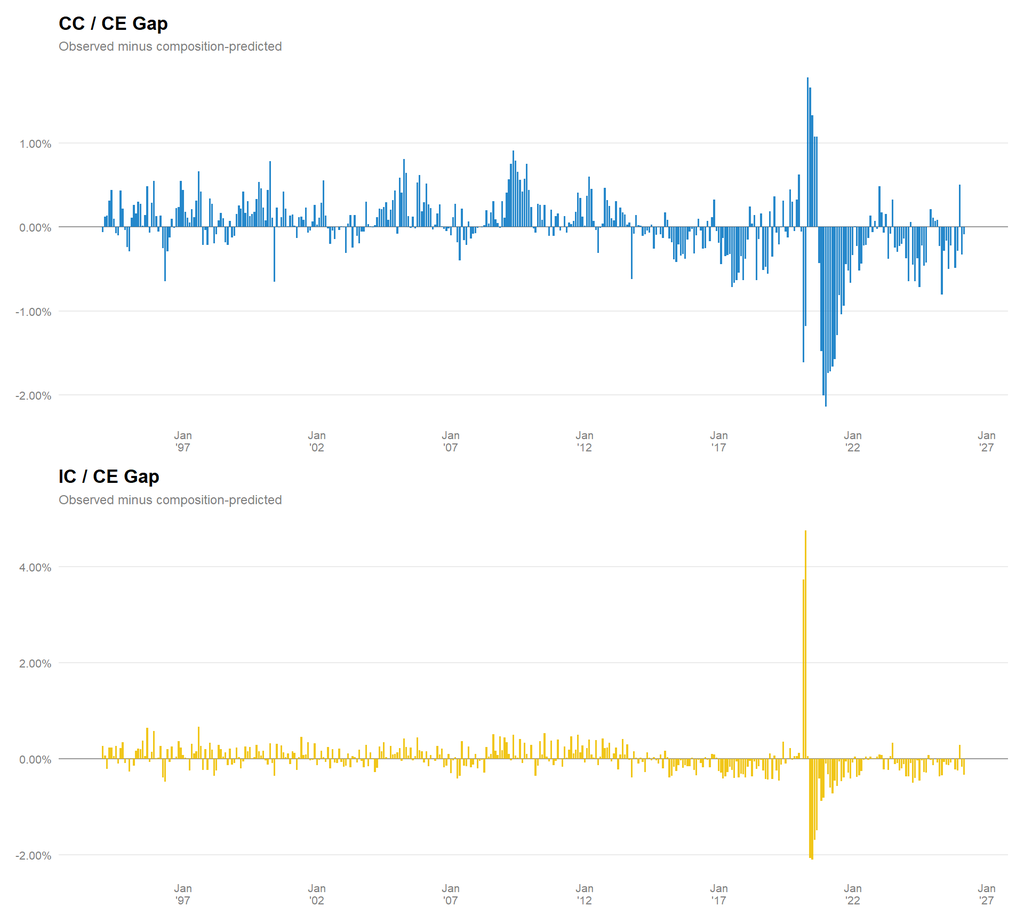

Figure 31: Gap between observed and composition-predicted national claims intensity, full monthly sample from 1994 onward. Negative values mean the composition model overpredicts.

```r
(ggplot(takeup_cause_fitted, aes(date, cc_gap)) +
   geom_hline(yintercept = 0, color = "grey60", linewidth = 0.5) +
   geom_col(fill = "#0073C2", alpha = 0.85, width = 25) +
   scale_x_date(date_breaks = "5 years", date_labels = "%b\n'%y") +
   scale_y_continuous(labels = percent_format(accuracy = 0.01)) +
   labs(title = "CC / CE Gap", subtitle = "Observed minus composition-predicted", x = NULL, y = NULL)) /
  (ggplot(takeup_cause_fitted, aes(date, ic_gap)) +
     geom_hline(yintercept = 0, color = "grey60", linewidth = 0.5) +
     geom_col(fill = "#EFC000", alpha = 0.9, width = 25) +
     scale_x_date(date_breaks = "5 years", date_labels = "%b\n'%y") +
     scale_y_continuous(labels = percent_format(accuracy = 0.01)) +
     labs(title = "IC / CE Gap", subtitle = "Observed minus composition-predicted", x = NULL, y = NULL))
```

The monthly observed-versus-predicted plots show that the composition benchmark tracks the broad level and cyclical swings of claims intensity well. But the gap plots also reveal the main result of the report: in the modern period, especially after the pandemic, observed claims intensity sits below the level historically associated with the realized unemployment mix.